```python
# Initialize Otter
import otter
grader = otter.Notebook("hw5.ipynb")
```

# CPSC 330 - Applied Machine Learning

## Homework 5: Putting it all together

### Associated lectures: All material till lecture 13

**Due date: See the [Calendar](https://htmlpreview.github.io/?https://github.com/UBC-CS/cpsc330/blob/master/docs/calendar.html).**

1. Submission instructions
2. Understanding the problem
3. Data splitting
4. EDA
5. (Optional) Feature engineering
6. Preprocessing and transformations
7. Baseline model
8. Linear models
9. Different models
10. (Optional) Feature selection
11. Hyperparameter optimization
12. Interpretation and feature importances
13. Results on the test set
14. Summary of the results
15. (Optional) Your takeaway from the course

# Final Score Report: 82%, Metric: Accuracy

## Submission instructions

rubric={points:4}

You will receive marks for correctly submitting this assignment. To submit this assignment, follow the instructions below:

- **You may work on this assignment in a group (group size <= 4) and submit your assignment as a group.**
- Below are some instructions on working as a group.
  - The maximum group size is 4.
  - You can choose your own group members.
  - Use group work as an opportunity to collaborate and learn new things from each other.
  - Be respectful to each other and make sure you understand all the concepts in the assignment well.
  - It's your responsibility to make sure that the assignment is submitted by one of the group members before the deadline. [Here](https://help.gradescope.com/article/m5qz2xsnjy-student-add-group-members) are some instructions on adding group members in Gradescope.
- Be sure to follow the [general lab instructions](https://ubc-mds.github.io/resources_pages/general_lab_instructions/).
- Upload the .ipynb file to Gradescope.
- **If the .ipynb file is too big or doesn't render on Gradescope for some reason, also upload a pdf or html in addition to the .ipynb.**
- Make sure that your plots/output are rendered properly in Gradescope.

## Imports

##### DISCLAIMER

One may need to install eli5, shap, and CatBoost in addition to the normal cpsc330 modules

```python
import os

%matplotlib inline
import string
import sys

import matplotlib.pyplot as plt
import numpy as np
import pandas as pd

from sklearn.compose import ColumnTransformer, make_column_transformer
from sklearn.dummy import DummyClassifier, DummyRegressor
from sklearn.ensemble import RandomForestClassifier, RandomForestRegressor
from sklearn.impute import SimpleImputer
from sklearn.linear_model import LogisticRegression
from sklearn.model_selection import (
    GridSearchCV,
    RandomizedSearchCV,
    cross_val_score,
    cross_validate,
    train_test_split,
)
from sklearn.pipeline import Pipeline, make_pipeline
from sklearn.preprocessing import OneHotEncoder, OrdinalEncoder, StandardScaler
from sklearn.svm import SVC, SVR
from sklearn.tree import DecisionTreeClassifier
```

```python
random_state_ = 123
```

## Introduction

In this homework you will be working on an open-ended mini-project, where you will put all the different things you have learned so far together to solve an interesting problem.

A few notes and tips when you work on this mini-project:

#### Tips

1. This mini-project is open-ended, and while working on it, there might be some situations where you'll have to use your own judgment and make your own decisions (as you would be doing when you work as a data scientist). Make sure you explain your decisions whenever necessary.
2. **Do not include everything you ever tried in your submission** -- it's fine just to have your final code. That said, your code should be reproducible and well-documented. For example, if you chose your hyperparameters based on some hyperparameter optimization experiment, you should leave in the code for that experiment so that someone else could re-run it and obtain the same hyperparameters, rather than mysteriously just setting the hyperparameters to some (carefully chosen) values in your code.
3. If you realize that you are repeating a lot of code try to organize it in functions. Clear presentation of your code, experiments, and results is the key to be successful in this lab. You may use code from lecture notes or previous lab solutions with appropriate attributions.

#### Assessment

We plan to grade fairly and leniently. We don't have some secret target score that you need to achieve to get a good grade. **You'll be assessed on demonstration of mastery of course topics, clear presentation, and the quality of your analysis and results.** For example, if you just have a bunch of code and no text or figures, that's not good. If you do a bunch of sane things and get a lower accuracy than your friend, don't sweat it.

#### A final note

Finally, this style of this "project" question is different from other assignments. It'll be up to you to decide when you're "done" -- in fact, this is one of the hardest parts of real projects. But please don't spend WAY too much time on this... perhaps "a few hours" (15-20 hours???) is a good guideline for this project . Of course if you're having fun you're welcome to spend as much time as you want! But, if so, try not to do it out of perfectionism or getting the best possible grade. Do it because you're learning and enjoying it. Students from the past cohorts have found such kind of labs useful and fun and I hope you enjoy it as well.

## 1. Pick your problem and explain the prediction problem

rubric={points:3}

In this mini project, you will be working on a classification problem of predicting whether a credit card client will default or not. For this problem, you will use [Default of Credit Card Clients Dataset](https://www.kaggle.com/uciml/default-of-credit-card-clients-dataset). In this data set, there are 30,000 examples and 24 features, and the goal is to estimate whether a person will default (fail to pay) their credit card bills; this column is labeled "default.payment.next.month" in the data. The rest of the columns can be used as features. You may take some ideas and compare your results with [the associated research paper](https://www.sciencedirect.com/science/article/pii/S0957417407006719), which is available through [the UBC library](https://www.library.ubc.ca/).

**Your tasks:**

1. Spend some time understanding the problem and what each feature means. You can find this information in the documentation on [the dataset page on Kaggle](https://www.kaggle.com/uciml/default-of-credit-card-clients-dataset). Write a few sentences on your initial thoughts on the problem and the dataset.
2. Download the dataset and read it as a pandas dataframe.

Solution_1

1. Some of the columns can be a little vague particularly education having a repeated value of unknown and there seem to be some correlation between some of the variables in an intuitive view. The data set seems to be a mix of ordinal, categorical, and numeric features in order to predict a binary feature (whether a credit card is default/ not). We agree with classification being the appropriate choice since we are predicting a binary feature. `ID` would not be relevant and we want to exclude `SEX` to not be discriminatory. The most important feature might be `PAY_#`.
1. We are now reading the dataset.

```python
credit_df = pd.read_csv("data/credit_card.csv")
credit_df
```

|  | ID | LIMIT_BAL | SEX | EDUCATION | MARRIAGE | AGE | PAY_0 | PAY_2 | PAY_3 | PAY_4 | ... | BILL_AMT4 | BILL_AMT5 | BILL_AMT6 | PAY_AMT1 | PAY_AMT2 | PAY_AMT3 | PAY_AMT4 | PAY_AMT5 | PAY_AMT6 | default.payment.next.month |
| --- | --- | --- | --- | --- | --- | --- | --- | --- | --- | --- | --- | --- | --- | --- | --- | --- | --- | --- | --- | --- | --- |
| 0 | 1 | 20000.0 | 2 | 2 | 1 | 24 | 2 | 2 | -1 | -1 | ... | 0.0 | 0.0 | 0.0 | 0.0 | 689.0 | 0.0 | 0.0 | 0.0 | 0.0 | 1 |
| 1 | 2 | 120000.0 | 2 | 2 | 2 | 26 | -1 | 2 | 0 | 0 | ... | 3272.0 | 3455.0 | 3261.0 | 0.0 | 1000.0 | 1000.0 | 1000.0 | 0.0 | 2000.0 | 1 |
| 2 | 3 | 90000.0 | 2 | 2 | 2 | 34 | 0 | 0 | 0 | 0 | ... | 14331.0 | 14948.0 | 15549.0 | 1518.0 | 1500.0 | 1000.0 | 1000.0 | 1000.0 | 5000.0 | 0 |
| 3 | 4 | 50000.0 | 2 | 2 | 1 | 37 | 0 | 0 | 0 | 0 | ... | 28314.0 | 28959.0 | 29547.0 | 2000.0 | 2019.0 | 1200.0 | 1100.0 | 1069.0 | 1000.0 | 0 |
| 4 | 5 | 50000.0 | 1 | 2 | 1 | 57 | -1 | 0 | -1 | 0 | ... | 20940.0 | 19146.0 | 19131.0 | 2000.0 | 36681.0 | 10000.0 | 9000.0 | 689.0 | 679.0 | 0 |
| ... | ... | ... | ... | ... | ... | ... | ... | ... | ... | ... | ... | ... | ... | ... | ... | ... | ... | ... | ... | ... | ... |
| 29995 | 29996 | 220000.0 | 1 | 3 | 1 | 39 | 0 | 0 | 0 | 0 | ... | 88004.0 | 31237.0 | 15980.0 | 8500.0 | 20000.0 | 5003.0 | 3047.0 | 5000.0 | 1000.0 | 0 |
| 29996 | 29997 | 150000.0 | 1 | 3 | 2 | 43 | -1 | -1 | -1 | -1 | ... | 8979.0 | 5190.0 | 0.0 | 1837.0 | 3526.0 | 8998.0 | 129.0 | 0.0 | 0.0 | 0 |
| 29997 | 29998 | 30000.0 | 1 | 2 | 2 | 37 | 4 | 3 | 2 | -1 | ... | 20878.0 | 20582.0 | 19357.0 | 0.0 | 0.0 | 22000.0 | 4200.0 | 2000.0 | 3100.0 | 1 |
| 29998 | 29999 | 80000.0 | 1 | 3 | 1 | 41 | 1 | -1 | 0 | 0 | ... | 52774.0 | 11855.0 | 48944.0 | 85900.0 | 3409.0 | 1178.0 | 1926.0 | 52964.0 | 1804.0 | 1 |
| 29999 | 30000 | 50000.0 | 1 | 2 | 1 | 46 | 0 | 0 | 0 | 0 | ... | 36535.0 | 32428.0 | 15313.0 | 2078.0 | 1800.0 | 1430.0 | 1000.0 | 1000.0 | 1000.0 | 1 |

30000 rows × 25 columns

## 2. Data splitting

rubric={points:2}

**Your tasks:**

1. Split the data into train (70%) and test (30%) portions with `random_state=123`.

> If your computer cannot handle training on 70% training data, make the test split bigger.

Solution_2

```python
from sklearn.model_selection import train_test_split

train_df, test_df = train_test_split(credit_df, test_size = 0.30, random_state=random_state_)
X_train, y_train = (
    train_df.drop(columns=["default.payment.next.month"]),
    train_df["default.payment.next.month"],
)
X_test, y_test = (
    test_df.drop(columns=["default.payment.next.month"]),
    test_df["default.payment.next.month"],
)
```

## 3. EDA

rubric={points:10}

**Your tasks:**

1. Perform exploratory data analysis on the train set.
2. Include at least two summary statistics and two visualizations that you find useful, and accompany each one with a sentence explaining it.
3. Summarize your initial observations about the data.
4. Pick appropriate metric/metrics for assessment.

Solution_3

## Preliminary EDA

```python
train_df.head()
```

|  | ID | LIMIT_BAL | SEX | EDUCATION | MARRIAGE | AGE | PAY_0 | PAY_2 | PAY_3 | PAY_4 | ... | BILL_AMT4 | BILL_AMT5 | BILL_AMT6 | PAY_AMT1 | PAY_AMT2 | PAY_AMT3 | PAY_AMT4 | PAY_AMT5 | PAY_AMT6 | default.payment.next.month |
| --- | --- | --- | --- | --- | --- | --- | --- | --- | --- | --- | --- | --- | --- | --- | --- | --- | --- | --- | --- | --- | --- |
| 16395 | 16396 | 320000.0 | 2 | 1 | 2 | 36 | 0 | 0 | 0 | 0 | ... | 19370.0 | 10155.0 | 3788.0 | 5000.0 | 5018.0 | 1000.0 | 3000.0 | 0.0 | 7013.0 | 0 |
| 21448 | 21449 | 440000.0 | 2 | 1 | 2 | 30 | -1 | -1 | -1 | 0 | ... | 171244.0 | 150897.0 | 117870.0 | 612.0 | 87426.0 | 130007.0 | 3018.0 | 15000.0 | 51663.0 | 0 |
| 20034 | 20035 | 160000.0 | 2 | 3 | 1 | 44 | -2 | -2 | -2 | -2 | ... | -18.0 | -18.0 | -18.0 | 0.0 | 0.0 | 0.0 | 0.0 | 0.0 | 0.0 | 0 |
| 25755 | 25756 | 120000.0 | 2 | 2 | 1 | 30 | 0 | 0 | 0 | 0 | ... | 103058.0 | 71095.0 | 47379.0 | 3706.0 | 5502.0 | 4204.0 | 3017.0 | 2005.0 | 1702.0 | 0 |
| 1438 | 1439 | 50000.0 | 1 | 2 | 2 | 54 | 1 | 2 | 0 | 0 | ... | 27585.0 | 27910.0 | 27380.0 | 0.0 | 1400.0 | 1200.0 | 1500.0 | 1000.0 | 1500.0 | 0 |

5 rows × 25 columns

```python
train_df.info()
```

```
<class 'pandas.core.frame.DataFrame'>
Int64Index: 21000 entries, 16395 to 19966
Data columns (total 25 columns):
 #   Column                      Non-Null Count  Dtype
---  ------                      --------------  -----
 0   ID                          21000 non-null  int64
 1   LIMIT_BAL                   21000 non-null  float64
 2   SEX                         21000 non-null  int64
 3   EDUCATION                   21000 non-null  int64
 4   MARRIAGE                    21000 non-null  int64
 5   AGE                         21000 non-null  int64
 6   PAY_0                       21000 non-null  int64
 7   PAY_2                       21000 non-null  int64
 8   PAY_3                       21000 non-null  int64
 9   PAY_4                       21000 non-null  int64
```

[output cut: 17 more lines]

Here we know that everything here are numeric features.

```python
train_df.describe()
```

|  | ID | LIMIT_BAL | SEX | EDUCATION | MARRIAGE | AGE | PAY_0 | PAY_2 | PAY_3 | PAY_4 | ... | BILL_AMT4 | BILL_AMT5 | BILL_AMT6 | PAY_AMT1 | PAY_AMT2 | PAY_AMT3 | PAY_AMT4 | PAY_AMT5 | PAY_AMT6 | default.payment.next.month |
| --- | --- | --- | --- | --- | --- | --- | --- | --- | --- | --- | --- | --- | --- | --- | --- | --- | --- | --- | --- | --- | --- |
| count | 21000.000000 | 21000.000000 | 21000.000000 | 21000.000000 | 21000.000000 | 21000.000000 | 21000.000000 | 21000.000000 | 21000.000000 | 21000.000000 | ... | 21000.000000 | 21000.000000 | 21000.000000 | 21000.000000 | 2.100000e+04 | 21000.000000 | 21000.000000 | 21000.000000 | 21000.000000 | 21000.000000 |
| mean | 14962.348238 | 167880.651429 | 1.600762 | 1.852143 | 1.554000 | 35.500810 | -0.015429 | -0.137095 | -0.171619 | -0.225238 | ... | 43486.610905 | 40428.518333 | 38767.202667 | 5673.585143 | 5.895027e+03 | 5311.432286 | 4774.021381 | 4751.850095 | 5237.762190 | 0.223238 |
| std | 8650.734050 | 130202.682167 | 0.489753 | 0.792961 | 0.521675 | 9.212644 | 1.120465 | 1.194506 | 1.196123 | 1.168556 | ... | 64843.303993 | 61187.200817 | 59587.689549 | 17033.241454 | 2.180143e+04 | 18377.997079 | 15434.136142 | 15228.193125 | 18116.846563 | 0.416427 |
| min | 1.000000 | 10000.000000 | 1.000000 | 0.000000 | 0.000000 | 21.000000 | -2.000000 | -2.000000 | -2.000000 | -2.000000 | ... | -50616.000000 | -61372.000000 | -339603.000000 | 0.000000 | 0.000000e+00 | 0.000000 | 0.000000 | 0.000000 | 0.000000 | 0.000000 |
| 25% | 7498.750000 | 50000.000000 | 1.000000 | 1.000000 | 1.000000 | 28.000000 | -1.000000 | -1.000000 | -1.000000 | -1.000000 | ... | 2293.750000 | 1739.500000 | 1215.750000 | 1000.000000 | 8.200000e+02 | 390.000000 | 266.000000 | 234.000000 | 110.750000 | 0.000000 |
| 50% | 14960.500000 | 140000.000000 | 2.000000 | 2.000000 | 2.000000 | 34.000000 | 0.000000 | 0.000000 | 0.000000 | 0.000000 | ... | 19102.500000 | 18083.000000 | 16854.500000 | 2100.000000 | 2.007000e+03 | 1809.500000 | 1500.000000 | 1500.000000 | 1500.000000 | 0.000000 |
| 75% | 22458.250000 | 240000.000000 | 2.000000 | 2.000000 | 2.000000 | 41.000000 | 0.000000 | 0.000000 | 0.000000 | 0.000000 | ... | 54763.250000 | 50491.000000 | 49253.750000 | 5007.250000 | 5.000000e+03 | 4628.500000 | 4021.250000 | 4016.000000 | 4000.000000 | 0.000000 |
| max | 30000.000000 | 1000000.000000 | 2.000000 | 6.000000 | 3.000000 | 79.000000 | 8.000000 | 8.000000 | 8.000000 | 8.000000 | ... | 891586.000000 | 927171.000000 | 961664.000000 | 873552.000000 | 1.227082e+06 | 896040.000000 | 621000.000000 | 426529.000000 | 528666.000000 | 1.000000 |

8 rows × 25 columns

We notice here some strange occurances, `PAY_#` Seems to have a min of -2 and a median of 0, which are values that are not explained in the dataset, and it only goes up to 8 instead of 9. One assumption is that 8 would be the maximum value instead of 9, and we merge -2, -1, and 0 into 0 to have it all simply mean paid duly.

Likewise, some of the `BILL_AMT#` have negative values, which is strange as one should not receive a negative bill, one Idea is to make this 0.

`EDUCATION` and `MARRIAGE` also has an unexpected 0 value. Which could be merged with the "other" and "unknown" values.

Other than that, it seems to be good so far, no NaN values.

## Visualization

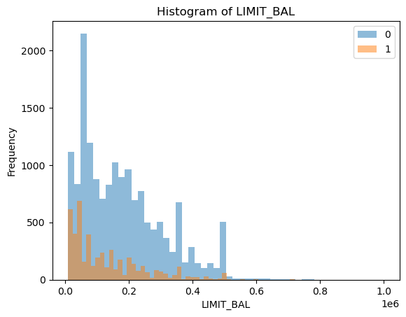

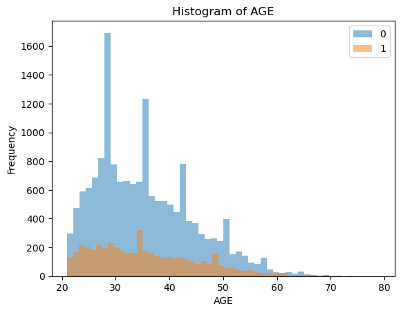

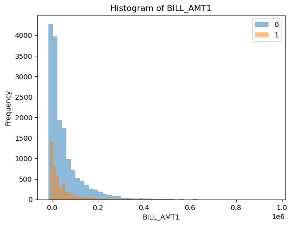

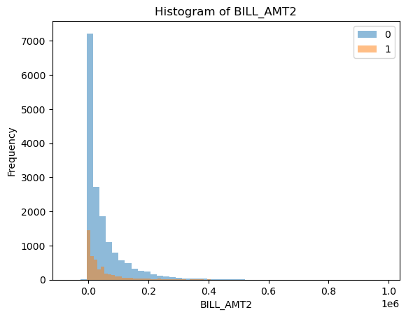

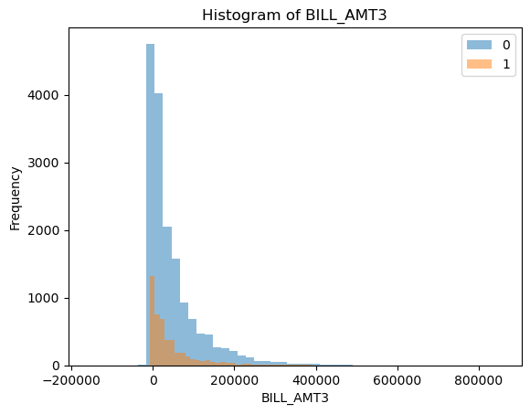

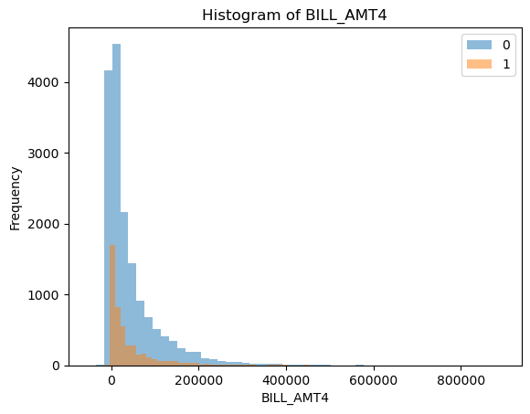

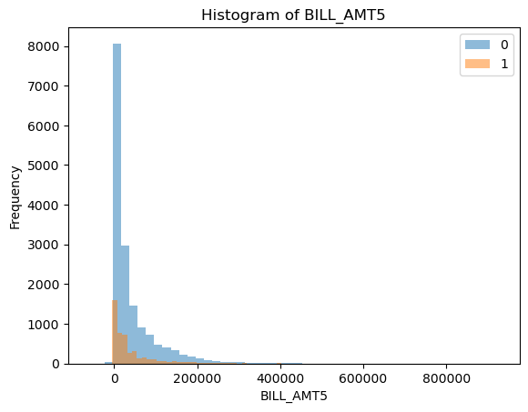

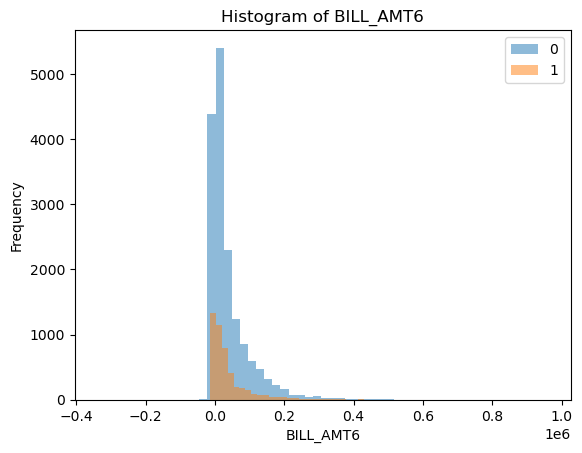

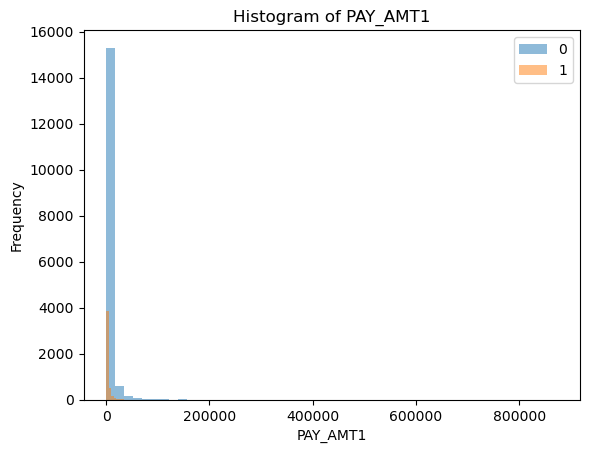

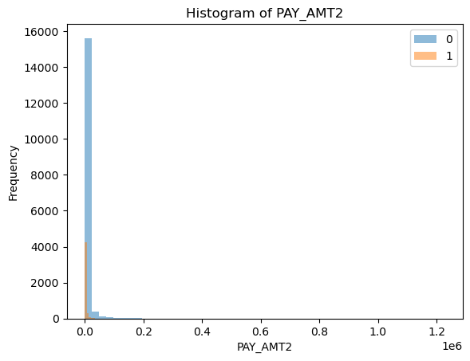

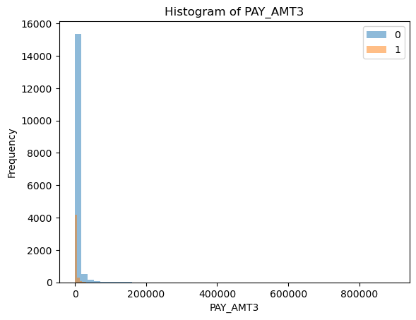

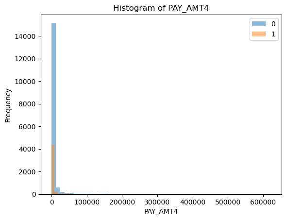

[2 more figures not shown]

```python
credit_plot = train_df.drop(columns = ["ID", "SEX", "EDUCATION", "MARRIAGE", "PAY_0", "PAY_2", "PAY_3", "PAY_4", "PAY_5", "PAY_6", "default.payment.next.month"])

for column in credit_plot:
    feat = column
    ax = train_df.groupby("default.payment.next.month")[feat].plot.hist(bins=50, alpha=0.5, legend=True)
    plt.xlabel(feat)
    plt.title("Histogram of " + feat)
    plt.show()
```

There are clearly quite the severe outliers on both `BILL_AMT#` and `PAY_AMT#` towards the right, though this could make sense if it is from people with a lot of money asking for large loans such as to start a business (some could even have overpaid and lead to negative in the next month, we cannot know for everything for sure behind why some people paid certain amounts over/under so we will not touch them). Considering the long tail ends of the frequency distributions and contrasting the mean and median values. No outlier removal may be necessary due to the rarity that larger loan amounts could occur and seem to not effect the values to a large degree, and it is unlikely to cause any "class discrimination" where class means the economic class of the individual.

It is interesting to note that visually, about every time a bill was negative, it resulted in paying back the full credit at the next month, which supports the hypothesis of it being credit that passed onto the bill. So we expect to also keep this value.

## (Optional) 4. Feature engineering

rubric={points:1}

**Your tasks:**

1. Carry out feature engineering. In other words, extract new features relevant for the problem and work with your new feature set in the following exercises. You may have to go back and forth between feature engineering and preprocessing.

Solution_4

```python
# Ignoring for the moment just to prioritize things
```

## 5. Preprocessing and transformations

rubric={points:10}

**Your tasks:**

1. Identify different feature types and the transformations you would apply on each feature type.
2. Define a column transformer, if necessary.

Solution_5

```python
# confirming the values
train_df["EDUCATION"].unique()
```

```
array([1, 3, 2, 5, 4, 6, 0])
```

```python
train_df["PAY_0"].unique()
```

```
array([ 0, -1, -2,  1,  2,  3,  5,  8,  7,  4,  6])
```

```python
#Making the changes in training and testing set (note this is not breaking the golden rule)

for column in ["PAY_0", "PAY_2", "PAY_3", "PAY_4", "PAY_5", "PAY_6"]:
    for not_accepted in [-2, -1]:
        train_df.loc[train_df[column] == not_accepted, column] = 0
        test_df.loc[test_df[column] == not_accepted, column] = 0

for column in ["MARRIAGE"]:
    train_df.loc[train_df[column] == 0, column] = 3
    test_df.loc[test_df[column] == 0, column] = 3

for column in ["EDUCATION"]:
    for not_accepted in [0, 5, 6]:
        train_df.loc[ train_df[column] == not_accepted, column] = 4
        test_df.loc[ test_df[column] == not_accepted, column] = 4
```

```python
# Inspired from https://ubc-cs.github.io/cpsc330/lectures/11_ensembles.html

# COLUMNS
numeric_features = ["BILL_AMT1", "BILL_AMT2", "BILL_AMT3", "BILL_AMT4", "BILL_AMT5", "BILL_AMT6",
                   "PAY_AMT1", "PAY_AMT2", "PAY_AMT3", "PAY_AMT4", "PAY_AMT5", "PAY_AMT6",
                   "LIMIT_BAL", "AGE"]
categorical_features = ["MARRIAGE"]
ordinal_features_education = ["EDUCATION"]
ordinal_features_pay = ["PAY_0", "PAY_2", "PAY_3", "PAY_4"]
# This will be explained below
ordinal_features_pay_56 = ["PAY_5", "PAY_6"]
# binary_features = ["SEX"]
drop_features = ["ID", "SEX"] # Dropping the feature to avoid gender based bias
target_column = "default.payment.next.month"

# drop_features = ["ID", "SEX", "PAY_0", "PAY_2", "PAY_3", "PAY_4"] # Debugging
```

```python
# Ordinal Order

# (1=graduate school, 2=university, 3=high school, 4=others)
education_levels = [
     1, 2, 3, 4,
]

# (0=pay duly, 1=payment delay for one month, 2=payment delay for two months, … 8=payment delay for eight months+)
pay_levels = [
    0, 1, 2, 3, 4, 5, 6, 7, 8,
]

# # For some reason in the entire dataset, pay 5 and 6 don't have a one month delay
# # As this happens for all 21000 rows, we will assume this is not a fluke and there may be a bank policy on months 5 and 6.
pay_levels_56 = [
    0, 2, 3, 4, 5, 6, 7, 8,
]
```

```python
assert set(education_levels) == set(train_df["EDUCATION"].unique())

assert set(pay_levels) == set(train_df["PAY_0"].unique())
assert set(pay_levels) == set(train_df["PAY_2"].unique())
assert set(pay_levels) == set(train_df["PAY_3"].unique())
assert set(pay_levels) == set(train_df["PAY_4"].unique())

assert set(pay_levels_56) == set(train_df["PAY_5"].unique())
assert set(pay_levels_56) == set(train_df["PAY_6"].unique())
```

```python
# Transformers and Preprocessing
numeric_transformer = make_pipeline(
    StandardScaler()
)

ordinal_transformer_education = make_pipeline(
    OrdinalEncoder(categories=[education_levels], dtype=int, handle_unknown="use_encoded_value", unknown_value = 4)
)

ordinal_transformer_pay = make_pipeline(
    OrdinalEncoder(dtype=int, handle_unknown="use_encoded_value", unknown_value = -1)
)

ordinal_transformer_pay_56 = make_pipeline(
    OrdinalEncoder(dtype=int, handle_unknown="use_encoded_value", unknown_value = -1)
)

categorical_transformer = make_pipeline(
    OneHotEncoder(categories="auto", handle_unknown="ignore")
)

preprocessor = make_column_transformer(
    (numeric_transformer, numeric_features),
    (ordinal_transformer_education, ordinal_features_education),
    (ordinal_transformer_pay, ordinal_features_pay),
    (ordinal_transformer_pay_56, ordinal_features_pay_56),
    (categorical_transformer, categorical_features),
    ("drop", drop_features),
)
```

```python
X_train = train_df.drop(columns=[target_column])
y_train = train_df[target_column]

X_test = test_df.drop(columns=[target_column])
y_test = test_df[target_column]
```

```python
preprocessor.fit(X_train, y_train)
preprocessor.named_transformers_
```

```
{'pipeline-1': Pipeline(steps=[('standardscaler', StandardScaler())]),
 'pipeline-2': Pipeline(steps=[('ordinalencoder',
                  OrdinalEncoder(categories=[[1, 2, 3, 4]], dtype=<class 'int'>,
                                 handle_unknown='use_encoded_value',
                                 unknown_value=4))]),
 'pipeline-3': Pipeline(steps=[('ordinalencoder',
                  OrdinalEncoder(dtype=<class 'int'>,
                                 handle_unknown='use_encoded_value',
                                 unknown_value=-1))]),
 'pipeline-4': Pipeline(steps=[('ordinalencoder',
                  OrdinalEncoder(dtype=<class 'int'>,
                                 handle_unknown='use_encoded_value',
                                 unknown_value=-1))]),
 'pipeline-5': Pipeline(steps=[('onehotencoder', OneHotEncoder(handle_unknown='ignore'))]),
 'drop': 'drop'}
```

```python
X_train.head()
```

|  | ID | LIMIT_BAL | SEX | EDUCATION | MARRIAGE | AGE | PAY_0 | PAY_2 | PAY_3 | PAY_4 | ... | BILL_AMT3 | BILL_AMT4 | BILL_AMT5 | BILL_AMT6 | PAY_AMT1 | PAY_AMT2 | PAY_AMT3 | PAY_AMT4 | PAY_AMT5 | PAY_AMT6 |
| --- | --- | --- | --- | --- | --- | --- | --- | --- | --- | --- | --- | --- | --- | --- | --- | --- | --- | --- | --- | --- | --- |
| 16395 | 16396 | 320000.0 | 2 | 1 | 2 | 36 | 0 | 0 | 0 | 0 | ... | 28695.0 | 19370.0 | 10155.0 | 3788.0 | 5000.0 | 5018.0 | 1000.0 | 3000.0 | 0.0 | 7013.0 |
| 21448 | 21449 | 440000.0 | 2 | 1 | 2 | 30 | 0 | 0 | 0 | 0 | ... | 87426.0 | 171244.0 | 150897.0 | 117870.0 | 612.0 | 87426.0 | 130007.0 | 3018.0 | 15000.0 | 51663.0 |
| 20034 | 20035 | 160000.0 | 2 | 3 | 1 | 44 | 0 | 0 | 0 | 0 | ... | -18.0 | -18.0 | -18.0 | -18.0 | 0.0 | 0.0 | 0.0 | 0.0 | 0.0 | 0.0 |
| 25755 | 25756 | 120000.0 | 2 | 2 | 1 | 30 | 0 | 0 | 0 | 0 | ... | 104694.0 | 103058.0 | 71095.0 | 47379.0 | 3706.0 | 5502.0 | 4204.0 | 3017.0 | 2005.0 | 1702.0 |
| 1438 | 1439 | 50000.0 | 1 | 2 | 2 | 54 | 1 | 2 | 0 | 0 | ... | 27168.0 | 27585.0 | 27910.0 | 27380.0 | 0.0 | 1400.0 | 1200.0 | 1500.0 | 1000.0 | 1500.0 |

5 rows × 24 columns

```python
y_train.head()
```

```
16395    0
21448    0
20034    0
25755    0
1438     0
Name: default.payment.next.month, dtype: int64
```

## 6. Baseline model

rubric={points:2}

**Your tasks:**

1. Try `scikit-learn`'s baseline model and report results.

Solution_6

```python
results = {}
```

```python
# We are choosing thisfrom sklearn.metrics import accuracy_score, f1_score, precision_score, recall_score
from sklearn.metrics import accuracy_score, f1_score, precision_score, recall_score

scoring_metric = ["accuracy",
    "precision",
] # TODO look at the model data
```

```python
# From https://ubc-cs.github.io/cpsc330/lectures/05_preprocessing-pipelines.html#ordinal-encoding-occasionally-recommended
def mean_std_cross_val_scores(model, X_train, y_train, **kwargs):

    scores = cross_validate(model, X_train, y_train, **kwargs, error_score='raise')

    mean_scores = pd.DataFrame(scores).mean()
    std_scores = pd.DataFrame(scores).std()
    out_col = []

    for i in range(len(mean_scores)):
        out_col.append((f"%0.3f (+/- %0.3f)" % (mean_scores[i], std_scores[i])))

    return pd.Series(data=out_col, index=mean_scores.index)
```

```python
# Dummy Baselike
dummy = DummyClassifier(strategy="stratified")
results["Dummy"] = mean_std_cross_val_scores(
    dummy, X_train, y_train, return_train_score=True, scoring=scoring_metric
)
```

```python
preprocessor
```

```
ColumnTransformer(transformers=[('pipeline-1',
                                 Pipeline(steps=[('standardscaler',
                                                  StandardScaler())]),
                                 ['BILL_AMT1', 'BILL_AMT2', 'BILL_AMT3',
                                  'BILL_AMT4', 'BILL_AMT5', 'BILL_AMT6',
                                  'PAY_AMT1', 'PAY_AMT2', 'PAY_AMT3',
                                  'PAY_AMT4', 'PAY_AMT5', 'PAY_AMT6',
                                  'LIMIT_BAL', 'AGE']),
                                ('pipeline-2',
                                 Pipeline(steps=[('ordinalencoder',
                                                  OrdinalEncoder(categories=[[1,
                                                                              2,
                                                                              3,
                                                                              4]],
                                                                 dtype...
                                                                 handle_unknown='use_encoded_value',
                                                                 unknown_value=-1))]),
                                 ['PAY_0', 'PAY_2', 'PAY_3', 'PAY_4']),
                                ('pipeline-4',
                                 Pipeline(steps=[('ordinalencoder',
                                                  OrdinalEncoder(dtype=<class 'int'>,
                                                                 handle_unknown='use_encoded_value',
                                                                 unknown_value=-1))]),
                                 ['PAY_5', 'PAY_6']),
                                ('pipeline-5',
                                 Pipeline(steps=[('onehotencoder',
                                                  OneHotEncoder(handle_unknown='ignore'))]),
                                 ['MARRIAGE']),
                                ('drop', 'drop', ['ID', 'SEX'])])
```

```python
pipe_dt = make_pipeline(preprocessor, DecisionTreeClassifier(random_state=random_state_))
results["Decision Tree"] = mean_std_cross_val_scores(
    pipe_dt, X_train, y_train, return_train_score=True, scoring=scoring_metric
)
```

```python
pd.DataFrame(results).T
```

|  | fit_time | score_time | test_accuracy | train_accuracy | test_precision | train_precision |
| --- | --- | --- | --- | --- | --- | --- |
| Dummy | 0.004 (+/- 0.002) | 0.004 (+/- 0.001) | 0.652 (+/- 0.006) | 0.654 (+/- 0.004) | 0.221 (+/- 0.009) | 0.223 (+/- 0.005) |
| Decision Tree | 0.414 (+/- 0.098) | 0.017 (+/- 0.008) | 0.723 (+/- 0.009) | 0.999 (+/- 0.000) | 0.386 (+/- 0.018) | 1.000 (+/- 0.000) |

We can see that the decision tree overfit, as expected, since decision trees are prone to overfitting. The dummy classifier didn't do a good job, as we can see the test score is very low, so it will not generalize to new data well. Both of these baseline models are not reliable and not recommended for the deployment data, since they generalized very poorly - as seen from the cross-validation scores.

## 7. Linear models

rubric={points:10}

**Your tasks:**

1. Try a linear model as a first real attempt.
2. Carry out hyperparameter tuning to explore different values for the complexity hyperparameter.
3. Report cross-validation scores along with standard deviation.
4. Summarize your results.

## Machine Learning Models

Solution_7

### 1. Linear Model (Logistic Regression)

```python
# linear model as first attempt
from sklearn.linear_model import LogisticRegression

# changing max_iter to deal with iterations reached limit
linear_model = LogisticRegression(max_iter = 1000)
linear_model.fit(X_train, y_train)
scores = cross_validate(linear_model, X_train, y_train, return_train_score = True)
pd.DataFrame(scores)
```

|  | fit_time | score_time | test_score | train_score |
| --- | --- | --- | --- | --- |
| 0 | 0.091213 | 0.002852 | 0.777143 | 0.776607 |
| 1 | 0.271847 | 0.002767 | 0.776905 | 0.776726 |
| 2 | 0.303057 | 0.002754 | 0.776667 | 0.776845 |
| 3 | 0.404678 | 0.004417 | 0.776667 | 0.776786 |
| 4 | 0.438092 | 0.002858 | 0.776667 | 0.776786 |

```python
# tuning different values for the complexity hyperparameter
# reference: https://ubc-cs.github.io/cpsc330/lectures/07_linear-models.html?highlight=scores_dict#main-hyperparameter-of-logistic-regression
scores_dict = {
    "C": 10.0 ** np.arange(-4, 6, 1),
    "mean_train_scores": list(),
    "mean_cv_scores": list(),
}
for C in scores_dict["C"]:
    linear_model = LogisticRegression(max_iter = 1000, C = C)
    scores = cross_validate(linear_model, X_train, y_train, return_train_score=True)
    scores_dict["mean_train_scores"].append(scores["train_score"].mean())
    scores_dict["mean_cv_scores"].append(scores["test_score"].mean())

results_df = pd.DataFrame(scores_dict)
results_df
```

|  | C | mean_train_scores | mean_cv_scores |
| --- | --- | --- | --- |
| 0 | 0.0001 | 0.776750 | 0.77681 |
| 1 | 0.0010 | 0.776762 | 0.77681 |
| 2 | 0.0100 | 0.776750 | 0.77681 |
| 3 | 0.1000 | 0.776750 | 0.77681 |
| 4 | 1.0000 | 0.776750 | 0.77681 |
| 5 | 10.0000 | 0.776750 | 0.77681 |
| 6 | 100.0000 | 0.776762 | 0.77681 |
| 7 | 1000.0000 | 0.776762 | 0.77681 |
| 8 | 10000.0000 | 0.776750 | 0.77681 |
| 9 | 100000.0000 | 0.776750 | 0.77681 |

```python
# report-cross validation scores along with standard deviation
results["Linear Model"] = mean_std_cross_val_scores(
    linear_model, X_train, y_train, return_train_score = True, scoring = scoring_metric
)
pd.DataFrame(results).T
```

|  | fit_time | score_time | test_accuracy | train_accuracy | test_precision | train_precision |
| --- | --- | --- | --- | --- | --- | --- |
| Dummy | 0.004 (+/- 0.002) | 0.004 (+/- 0.001) | 0.652 (+/- 0.006) | 0.654 (+/- 0.004) | 0.221 (+/- 0.009) | 0.223 (+/- 0.005) |
| Decision Tree | 0.414 (+/- 0.098) | 0.017 (+/- 0.008) | 0.723 (+/- 0.009) | 0.999 (+/- 0.000) | 0.386 (+/- 0.018) | 1.000 (+/- 0.000) |
| Linear Model | 0.363 (+/- 0.302) | 0.009 (+/- 0.003) | 0.777 (+/- 0.000) | 0.777 (+/- 0.000) | 0.200 (+/- 0.447) | 0.500 (+/- 0.354) |

## 8. Different models

rubric={points:12}

**Your tasks:**

1. Try at least 3 other models aside from a linear model. One of these models should be a tree-based ensemble model.
2. Summarize your results in terms of overfitting/underfitting and fit and score times. Can you beat a linear model?

Solution_8

### 2. K-Nearest Neighbors with K = 3 (Unoptimized)

```python
# importing k-nn classifier
from sklearn.neighbors import KNeighborsClassifier

# setting number of neighbors to 3 since k = 1 will definitely overfit
knn_model = make_pipeline(preprocessor, KNeighborsClassifier(n_neighbors = 3))
results["K-NN"] = mean_std_cross_val_scores(
    knn_model, X_train, y_train, return_train_score = True, scoring = scoring_metric
)
pd.DataFrame(results).T
```

|  | fit_time | score_time | test_accuracy | train_accuracy | test_precision | train_precision |
| --- | --- | --- | --- | --- | --- | --- |
| Dummy | 0.004 (+/- 0.002) | 0.004 (+/- 0.001) | 0.652 (+/- 0.006) | 0.654 (+/- 0.004) | 0.221 (+/- 0.009) | 0.223 (+/- 0.005) |
| Decision Tree | 0.414 (+/- 0.098) | 0.017 (+/- 0.008) | 0.723 (+/- 0.009) | 0.999 (+/- 0.000) | 0.386 (+/- 0.018) | 1.000 (+/- 0.000) |
| Linear Model | 0.363 (+/- 0.302) | 0.009 (+/- 0.003) | 0.777 (+/- 0.000) | 0.777 (+/- 0.000) | 0.200 (+/- 0.447) | 0.500 (+/- 0.354) |
| K-NN | 0.037 (+/- 0.014) | 0.448 (+/- 0.132) | 0.776 (+/- 0.003) | 0.864 (+/- 0.001) | 0.497 (+/- 0.011) | 0.763 (+/- 0.005) |

### 3. Random Forest (Tree-based Ensemble Model)

```python
# importing random forest classifier
from sklearn.ensemble import RandomForestClassifier
random_forest_model = make_pipeline(
    preprocessor, RandomForestClassifier(random_state = random_state_, n_jobs = -1)
)
results["Random Forests"] = mean_std_cross_val_scores(
    random_forest_model, X_train, y_train, return_train_score = True, scoring = scoring_metric
)
pd.DataFrame(results).T
```

|  | fit_time | score_time | test_accuracy | train_accuracy | test_precision | train_precision |
| --- | --- | --- | --- | --- | --- | --- |
| Dummy | 0.004 (+/- 0.002) | 0.004 (+/- 0.001) | 0.652 (+/- 0.006) | 0.654 (+/- 0.004) | 0.221 (+/- 0.009) | 0.223 (+/- 0.005) |
| Decision Tree | 0.414 (+/- 0.098) | 0.017 (+/- 0.008) | 0.723 (+/- 0.009) | 0.999 (+/- 0.000) | 0.386 (+/- 0.018) | 1.000 (+/- 0.000) |
| Linear Model | 0.363 (+/- 0.302) | 0.009 (+/- 0.003) | 0.777 (+/- 0.000) | 0.777 (+/- 0.000) | 0.200 (+/- 0.447) | 0.500 (+/- 0.354) |
| K-NN | 0.037 (+/- 0.014) | 0.448 (+/- 0.132) | 0.776 (+/- 0.003) | 0.864 (+/- 0.001) | 0.497 (+/- 0.011) | 0.763 (+/- 0.005) |
| Random Forests | 2.660 (+/- 0.923) | 0.075 (+/- 0.008) | 0.814 (+/- 0.006) | 0.999 (+/- 0.000) | 0.647 (+/- 0.028) | 0.999 (+/- 0.000) |

### 4. CatBoost (Ensemble Model)

```python
# importing catboost classifier
from catboost import CatBoostClassifier

catboost_model = make_pipeline(preprocessor, CatBoostClassifier(verbose = 0, random_state = random_state_))
results["CatBoost"] = mean_std_cross_val_scores(
    catboost_model, X_train, y_train, return_train_score = True, scoring = scoring_metric
)
pd.DataFrame(results).T
```

|  | fit_time | score_time | test_accuracy | train_accuracy | test_precision | train_precision |
| --- | --- | --- | --- | --- | --- | --- |
| Dummy | 0.004 (+/- 0.002) | 0.004 (+/- 0.001) | 0.652 (+/- 0.006) | 0.654 (+/- 0.004) | 0.221 (+/- 0.009) | 0.223 (+/- 0.005) |
| Decision Tree | 0.414 (+/- 0.098) | 0.017 (+/- 0.008) | 0.723 (+/- 0.009) | 0.999 (+/- 0.000) | 0.386 (+/- 0.018) | 1.000 (+/- 0.000) |
| Linear Model | 0.363 (+/- 0.302) | 0.009 (+/- 0.003) | 0.777 (+/- 0.000) | 0.777 (+/- 0.000) | 0.200 (+/- 0.447) | 0.500 (+/- 0.354) |
| K-NN | 0.037 (+/- 0.014) | 0.448 (+/- 0.132) | 0.776 (+/- 0.003) | 0.864 (+/- 0.001) | 0.497 (+/- 0.011) | 0.763 (+/- 0.005) |
| Random Forests | 2.660 (+/- 0.923) | 0.075 (+/- 0.008) | 0.814 (+/- 0.006) | 0.999 (+/- 0.000) | 0.647 (+/- 0.028) | 0.999 (+/- 0.000) |
| CatBoost | 11.625 (+/- 3.160) | 0.051 (+/- 0.015) | 0.817 (+/- 0.004) | 0.861 (+/- 0.002) | 0.660 (+/- 0.019) | 0.821 (+/- 0.008) |

## (Optional) 9. Feature selection

rubric={points:2}

**Your tasks:**

Make some attempts to select relevant features. You may try `RFECV` or forward selection for this. Do the results improve with feature selection? Summarize your results. If you see improvements in the results, keep feature selection in your pipeline. If not, you may abandon it in the next exercises.

Solution_9

```python
# ignoring for now to focus on other parts
```

## 10. Hyperparameter optimization

rubric={points:10}

**Your tasks:**

Make some attempts to optimize hyperparameters for the models you've tried and summarize your results. In at least one case you should be optimizing multiple hyperparameters for a single model. You may use `sklearn`'s methods for hyperparameter optimization or fancier Bayesian optimization methods.

- [GridSearchCV](http://scikit-learn.org/stable/modules/generated/sklearn.model_selection.GridSearchCV.html)
- [RandomizedSearchCV](http://scikit-learn.org/stable/modules/generated/sklearn.model_selection.RandomizedSearchCV.html)
- scikit-optimize

Solution_10

We can see that from the previous parts we haven't did hyperparameter tuning in order to achieve a better model overall. We will hence do hyperparameter optimization here. We will start with optimizing our K-NN model here.

### 5. Optimized K-Nearest Neighbors

```python
# choosing the best hyperparameter k
# reference: https://ubc-cs.github.io/cpsc330/lectures/04_kNNs-SVM-RBF.html#how-to-choose-n-neighbors
results_dict = {
    "n_neighbors": [],
    "mean_train_score": [],
    "mean_cv_score": [],
    "std_cv_score": [],
    "std_train_score": [],
}
param_grid = {"n_neighbors": np.arange(1, 50, 2)}

for k in param_grid["n_neighbors"]:
    knn = KNeighborsClassifier(n_neighbors=k)
    scores = cross_validate(knn, X_train, y_train, return_train_score=True)
    results_dict["n_neighbors"].append(k)

    results_dict["mean_cv_score"].append(np.mean(scores["test_score"]))
    results_dict["mean_train_score"].append(np.mean(scores["train_score"]))
    results_dict["std_cv_score"].append(scores["test_score"].std())
    results_dict["std_train_score"].append(scores["train_score"].std())

results_df = pd.DataFrame(results_dict)
results_df = results_df.set_index("n_neighbors")
results_df
```

| n_neighbors | mean_train_score | mean_cv_score | std_cv_score | std_train_score |
| --- | --- | --- | --- | --- |
| 1 | 1.000000 | 0.686095 | 0.007413 | 0.000000 |
| 3 | 0.840714 | 0.727905 | 0.007524 | 0.002129 |
| 5 | 0.811405 | 0.743000 | 0.003832 | 0.001077 |
| 7 | 0.801155 | 0.755762 | 0.003365 | 0.001377 |
| 9 | 0.794988 | 0.760000 | 0.004475 | 0.001192 |
| 11 | 0.791083 | 0.764095 | 0.002700 | 0.001524 |
| 13 | 0.788929 | 0.767143 | 0.003512 | 0.001639 |
| 15 | 0.786262 | 0.767000 | 0.003277 | 0.001202 |
| 17 | 0.784750 | 0.768762 | 0.002137 | 0.000486 |
| 19 | 0.783143 | 0.770048 | 0.001937 | 0.001084 |
| 21 | 0.782667 | 0.770381 | 0.002393 | 0.000916 |
| 23 | 0.781536 | 0.770810 | 0.002393 | 0.000850 |
| 25 | 0.780893 | 0.772048 | 0.002563 | 0.000719 |
| 27 | 0.780143 | 0.772286 | 0.001995 | 0.001095 |
| 29 | 0.780405 | 0.773095 | 0.002885 | 0.001105 |
| 31 | 0.779738 | 0.773571 | 0.002239 | 0.000626 |
| 33 | 0.779464 | 0.773190 | 0.001417 | 0.000785 |
| 35 | 0.778952 | 0.774048 | 0.001832 | 0.000852 |
| 37 | 0.778881 | 0.774762 | 0.001826 | 0.000500 |
| 39 | 0.778893 | 0.774429 | 0.000923 | 0.000401 |
| 41 | 0.778893 | 0.773857 | 0.001290 | 0.000699 |
| 43 | 0.778571 | 0.775048 | 0.001561 | 0.000705 |
| 45 | 0.778571 | 0.774905 | 0.001734 | 0.000682 |
| 47 | 0.778310 | 0.774905 | 0.001872 | 0.000679 |
| 49 | 0.778333 | 0.775143 | 0.001182 | 0.000431 |

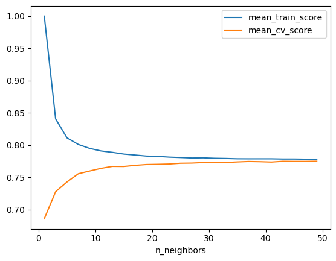

```python
results_df[["mean_train_score", "mean_cv_score"]].plot();
```

```python
# choosing the best number of neighbors with the greatest cross-validation scores
best_n_neighbours = results_df.idxmax()["mean_cv_score"]
best_n_neighbours
```

```
49
```

```python
# k-nn withh optimized hyperparameter
from sklearn.neighbors import KNeighborsClassifier

# passing the best k value to the model
knn_model_new = make_pipeline(preprocessor, KNeighborsClassifier(n_neighbors = best_n_neighbours))
results["K-NN Optimized"] = mean_std_cross_val_scores(
    knn_model_new, X_train, y_train, return_train_score=True, scoring = scoring_metric
)
pd.DataFrame(results).T
```

|  | fit_time | score_time | test_accuracy | train_accuracy | test_precision | train_precision |
| --- | --- | --- | --- | --- | --- | --- |
| Dummy | 0.004 (+/- 0.002) | 0.004 (+/- 0.001) | 0.652 (+/- 0.006) | 0.654 (+/- 0.004) | 0.221 (+/- 0.009) | 0.223 (+/- 0.005) |
| Decision Tree | 0.414 (+/- 0.098) | 0.017 (+/- 0.008) | 0.723 (+/- 0.009) | 0.999 (+/- 0.000) | 0.386 (+/- 0.018) | 1.000 (+/- 0.000) |
| Linear Model | 0.363 (+/- 0.302) | 0.009 (+/- 0.003) | 0.777 (+/- 0.000) | 0.777 (+/- 0.000) | 0.200 (+/- 0.447) | 0.500 (+/- 0.354) |
| K-NN | 0.037 (+/- 0.014) | 0.448 (+/- 0.132) | 0.776 (+/- 0.003) | 0.864 (+/- 0.001) | 0.497 (+/- 0.011) | 0.763 (+/- 0.005) |
| Random Forests | 2.660 (+/- 0.923) | 0.075 (+/- 0.008) | 0.814 (+/- 0.006) | 0.999 (+/- 0.000) | 0.647 (+/- 0.028) | 0.999 (+/- 0.000) |
| CatBoost | 11.625 (+/- 3.160) | 0.051 (+/- 0.015) | 0.817 (+/- 0.004) | 0.861 (+/- 0.002) | 0.660 (+/- 0.019) | 0.821 (+/- 0.008) |
| K-NN Optimized | 0.036 (+/- 0.006) | 0.503 (+/- 0.108) | 0.814 (+/- 0.004) | 0.818 (+/- 0.000) | 0.660 (+/- 0.022) | 0.678 (+/- 0.004) |

### 6. Optimized Random Forest with `GridSearchCV`

```python
forest_pipe = Pipeline(
     [
        ("preprocess", preprocessor),
        ("rf", RandomForestClassifier(random_state = random_state_, n_jobs = -1)),
    ]
)
```

```python
from sklearn.model_selection import GridSearchCV

# reference: https://ubc-cs.github.io/cpsc330/lectures/08_hyperparameter-optimization.html?highlight=gridsearchcv#the-syntax
param_grid = {
    "rf__n_estimators": [2, 5, 10, 15, 20, 25],
    "rf__max_depth": [1, 3, 5, 7, 10, 15, 20],
}

rforest_grid_search = GridSearchCV(
    forest_pipe, param_grid, cv = 5, n_jobs = -1, return_train_score=True
)
```

```python
from sklearn import set_config
set_config(display = "diagram")
```

```python
rforest_grid_search.fit(X_train, y_train)
```

```
GridSearchCV(cv=5,
             estimator=Pipeline(steps=[('preprocess',
                                        ColumnTransformer(transformers=[('pipeline-1',
                                                                         Pipeline(steps=[('standardscaler',
                                                                                          StandardScaler())]),
                                                                         ['BILL_AMT1',
                                                                          'BILL_AMT2',
                                                                          'BILL_AMT3',
                                                                          'BILL_AMT4',
                                                                          'BILL_AMT5',
                                                                          'BILL_AMT6',
                                                                          'PAY_AMT1',
                                                                          'PAY_AMT2',
                                                                          'PAY_AMT3',
                                                                          'PAY_AMT4',
                                                                          'PAY_AMT5',
                                                                          'PAY_AMT6',
                                                                          'LIMIT_BAL',
                                                                          'AGE']),
                                                                        ('pipeline-2',
                                                                         Pipeline(steps=[('o...
                                                                                                         unknown_value=-1))]),
                                                                         ['PAY_5',
                                                                          'PAY_6']),
                                                                        ('pipeline-5',
                                                                         Pipeline(steps=[('onehotencoder',
                                                                                          OneHotEncoder(handle_unknown='ignore'))]),
                                                                         ['MARRIAGE']),
                                                                        ('drop',
                                                                         'drop',
                                                                         ['ID',
                                                                          'SEX'])])),
                                       ('rf',
                                        RandomForestClassifier(n_jobs=-1,
                                                               random_state=123))]),
             n_jobs=-1,
             param_grid={'rf__max_depth': [1, 3, 5, 7, 10, 15, 20],
                         'rf__n_estimators': [2, 5, 10, 15, 20, 25]},
             return_train_score=True)
```

```python
rforest_grid_search.best_score_
```

```
0.8178095238095237
```

```python
rforest_grid_search.best_params_
```

```
{'rf__max_depth': 10, 'rf__n_estimators': 25}
```

```python
random_forest_optimization_results = pd.DataFrame(rforest_grid_search.cv_results_)
random_forest_optimization_results.T
```

|  | 0 | 1 | 2 | 3 | 4 | 5 | 6 | 7 | 8 | 9 | ... | 32 | 33 | 34 | 35 | 36 | 37 | 38 | 39 | 40 | 41 |
| --- | --- | --- | --- | --- | --- | --- | --- | --- | --- | --- | --- | --- | --- | --- | --- | --- | --- | --- | --- | --- | --- |
| mean_fit_time | 0.178684 | 0.197033 | 0.137641 | 0.194824 | 0.386988 | 0.405951 | 0.179997 | 0.155796 | 0.204303 | 0.242224 | ... | 1.072514 | 1.162437 | 1.49398 | 1.713618 | 0.213225 | 0.671991 | 1.059387 | 1.360729 | 1.453357 | 1.383807 |
| std_fit_time | 0.027313 | 0.036044 | 0.014584 | 0.036466 | 0.099251 | 0.047515 | 0.025396 | 0.060087 | 0.045877 | 0.029901 | ... | 0.13212 | 0.057868 | 0.087789 | 0.172647 | 0.047248 | 0.19861 | 0.158804 | 0.176866 | 0.032796 | 0.314593 |
| mean_score_time | 0.045056 | 0.036378 | 0.037472 | 0.049391 | 0.087247 | 0.078268 | 0.036247 | 0.057398 | 0.038424 | 0.046023 | ... | 0.034854 | 0.030436 | 0.031682 | 0.028766 | 0.030575 | 0.030045 | 0.028506 | 0.025695 | 0.032675 | 0.027031 |
| std_score_time | 0.026577 | 0.019255 | 0.012077 | 0.024245 | 0.017079 | 0.031534 | 0.014271 | 0.025453 | 0.007959 | 0.017347 | ... | 0.011808 | 0.003329 | 0.003193 | 0.002183 | 0.011995 | 0.007953 | 0.002791 | 0.001944 | 0.00738 | 0.002193 |
| param_rf__max_depth | 1 | 1 | 1 | 1 | 1 | 1 | 3 | 3 | 3 | 3 | ... | 15 | 15 | 15 | 15 | 20 | 20 | 20 | 20 | 20 | 20 |
| param_rf__n_estimators | 2 | 5 | 10 | 15 | 20 | 25 | 2 | 5 | 10 | 15 | ... | 10 | 15 | 20 | 25 | 2 | 5 | 10 | 15 | 20 | 25 |
| params | {'rf__max_depth': 1, 'rf__n_estimators': 2} | {'rf__max_depth': 1, 'rf__n_estimators': 5} | {'rf__max_depth': 1, 'rf__n_estimators': 10} | {'rf__max_depth': 1, 'rf__n_estimators': 15} | {'rf__max_depth': 1, 'rf__n_estimators': 20} | {'rf__max_depth': 1, 'rf__n_estimators': 25} | {'rf__max_depth': 3, 'rf__n_estimators': 2} | {'rf__max_depth': 3, 'rf__n_estimators': 5} | {'rf__max_depth': 3, 'rf__n_estimators': 10} | {'rf__max_depth': 3, 'rf__n_estimators': 15} | ... | {'rf__max_depth': 15, 'rf__n_estimators': 10} | {'rf__max_depth': 15, 'rf__n_estimators': 15} | {'rf__max_depth': 15, 'rf__n_estimators': 20} | {'rf__max_depth': 15, 'rf__n_estimators': 25} | {'rf__max_depth': 20, 'rf__n_estimators': 2} | {'rf__max_depth': 20, 'rf__n_estimators': 5} | {'rf__max_depth': 20, 'rf__n_estimators': 10} | {'rf__max_depth': 20, 'rf__n_estimators': 15} | {'rf__max_depth': 20, 'rf__n_estimators': 20} | {'rf__max_depth': 20, 'rf__n_estimators': 25} |
| split0_test_score | 0.790952 | 0.783571 | 0.776905 | 0.780714 | 0.776905 | 0.777381 | 0.80619 | 0.798095 | 0.802857 | 0.807857 | ... | 0.806429 | 0.810476 | 0.807857 | 0.812381 | 0.757143 | 0.789286 | 0.800476 | 0.802857 | 0.802381 | 0.804286 |
| split1_test_score | 0.796667 | 0.786905 | 0.776905 | 0.784524 | 0.776905 | 0.776905 | 0.810238 | 0.80381 | 0.80381 | 0.806429 | ... | 0.80381 | 0.812381 | 0.814762 | 0.812857 | 0.767619 | 0.794286 | 0.809286 | 0.81 | 0.81381 | 0.816905 |
| split2_test_score | 0.804762 | 0.786905 | 0.776667 | 0.780476 | 0.776667 | 0.776667 | 0.815952 | 0.801667 | 0.80119 | 0.807619 | ... | 0.815476 | 0.817619 | 0.816667 | 0.819762 | 0.771667 | 0.801667 | 0.811905 | 0.817857 | 0.811667 | 0.817143 |
| split3_test_score | 0.801667 | 0.785238 | 0.776667 | 0.78119 | 0.776667 | 0.776667 | 0.805476 | 0.794524 | 0.796667 | 0.804286 | ... | 0.812857 | 0.814524 | 0.817619 | 0.815476 | 0.767143 | 0.80119 | 0.810476 | 0.81619 | 0.817619 | 0.819524 |
| split4_test_score | 0.794286 | 0.78381 | 0.776667 | 0.782857 | 0.776667 | 0.776667 | 0.800238 | 0.797619 | 0.799286 | 0.801667 | ... | 0.806905 | 0.808333 | 0.81 | 0.811429 | 0.752619 | 0.792143 | 0.802143 | 0.808571 | 0.80619 | 0.810238 |
| mean_test_score | 0.797667 | 0.785286 | 0.776762 | 0.781952 | 0.776762 | 0.776857 | 0.807619 | 0.799143 | 0.800762 | 0.805571 | ... | 0.809095 | 0.812667 | 0.813381 | 0.814381 | 0.763238 | 0.795714 | 0.806857 | 0.811095 | 0.810333 | 0.813619 |
| std_test_score | 0.004977 | 0.00144 | 0.000117 | 0.001531 | 0.000117 | 0.000278 | 0.005242 | 0.003253 | 0.002562 | 0.002326 | ... | 0.004352 | 0.003213 | 0.003811 | 0.003006 | 0.007147 | 0.00493 | 0.004635 | 0.005424 | 0.005429 | 0.005597 |
| rank_test_score | 34 | 36 | 39 | 37 | 39 | 38 | 23 | 33 | 31 | 29 | ... | 18 | 10 | 9 | 6 | 42 | 35 | 24 | 14 | 17 | 8 |
| split0_train_score | 0.799286 | 0.786012 | 0.776726 | 0.782798 | 0.776726 | 0.778036 | 0.81631 | 0.801845 | 0.801726 | 0.806667 | ... | 0.905476 | 0.907083 | 0.911012 | 0.909821 | 0.89506 | 0.931131 | 0.942143 | 0.946548 | 0.947976 | 0.94881 |
| split1_train_score | 0.797857 | 0.785179 | 0.776726 | 0.781845 | 0.776726 | 0.776726 | 0.813214 | 0.799226 | 0.801488 | 0.806369 | ... | 0.908155 | 0.909286 | 0.909048 | 0.908393 | 0.895417 | 0.936012 | 0.946131 | 0.949048 | 0.949524 | 0.950833 |
| split2_train_score | 0.795893 | 0.785298 | 0.776786 | 0.781964 | 0.776786 | 0.776786 | 0.808929 | 0.79881 | 0.798512 | 0.804583 | ... | 0.906905 | 0.907738 | 0.907738 | 0.9075 | 0.896607 | 0.933988 | 0.945536 | 0.949345 | 0.950476 | 0.952619 |
| split3_train_score | 0.796607 | 0.785476 | 0.776786 | 0.781548 | 0.776786 | 0.776786 | 0.8075 | 0.799762 | 0.800833 | 0.805298 | ... | 0.90625 | 0.90756 | 0.90869 | 0.908274 | 0.895119 | 0.934643 | 0.942024 | 0.945655 | 0.947976 | 0.949167 |
| split4_train_score | 0.798452 | 0.785357 | 0.776786 | 0.783512 | 0.776786 | 0.776786 | 0.8075 | 0.80244 | 0.803571 | 0.807976 | ... | 0.905893 | 0.907738 | 0.906786 | 0.907321 | 0.897143 | 0.932738 | 0.946726 | 0.951429 | 0.954762 | 0.953452 |
| mean_train_score | 0.797619 | 0.785464 | 0.776762 | 0.782333 | 0.776762 | 0.777024 | 0.81069 | 0.800417 | 0.801226 | 0.806179 | ... | 0.906536 | 0.907881 | 0.908655 | 0.908262 | 0.895869 | 0.933702 | 0.944512 | 0.948405 | 0.950143 | 0.950976 |
| std_train_score | 0.001227 | 0.00029 | 0.000029 | 0.000721 | 0.000029 | 0.000506 | 0.003504 | 0.001454 | 0.001633 | 0.001168 | ... | 0.000935 | 0.000742 | 0.001417 | 0.000885 | 0.000847 | 0.001664 | 0.002019 | 0.002071 | 0.002499 | 0.001834 |

22 rows × 42 columns

```python
random_forest_optimization_results = (
    pd.DataFrame(rforest_grid_search.cv_results_).set_index("rank_test_score").sort_index()
)
display(random_forest_optimization_results.T)
```

| rank_test_score | 1 | 2 | 3 | 4 | 5 | 6 | 7 | 8 | 9 | 10 | ... | 33 | 34 | 35 | 36 | 37 | 38 | 39 | 39 | 41 | 42 |
| --- | --- | --- | --- | --- | --- | --- | --- | --- | --- | --- | --- | --- | --- | --- | --- | --- | --- | --- | --- | --- | --- |
| mean_fit_time | 1.277421 | 1.050687 | 0.884166 | 0.575871 | 0.71012 | 1.713618 | 1.044689 | 1.383807 | 1.49398 | 1.162437 | ... | 0.155796 | 0.178684 | 0.671991 | 0.197033 | 0.194824 | 0.405951 | 0.386988 | 0.137641 | 0.214126 | 0.213225 |
| std_fit_time | 0.067162 | 0.163828 | 0.070966 | 0.103454 | 0.118723 | 0.172647 | 0.083751 | 0.314593 | 0.087789 | 0.057868 | ... | 0.060087 | 0.027313 | 0.19861 | 0.036044 | 0.036466 | 0.047515 | 0.099251 | 0.014584 | 0.058166 | 0.047248 |
| mean_score_time | 0.035293 | 0.025694 | 0.034188 | 0.049336 | 0.042996 | 0.028766 | 0.03331 | 0.027031 | 0.031682 | 0.030436 | ... | 0.057398 | 0.045056 | 0.030045 | 0.036378 | 0.049391 | 0.078268 | 0.087247 | 0.037472 | 0.052468 | 0.030575 |
| std_score_time | 0.00274 | 0.001373 | 0.014597 | 0.014793 | 0.015225 | 0.002183 | 0.003434 | 0.002193 | 0.003193 | 0.003329 | ... | 0.025453 | 0.026577 | 0.007953 | 0.019255 | 0.024245 | 0.031534 | 0.017079 | 0.012077 | 0.024458 | 0.011995 |
| param_rf__max_depth | 10 | 10 | 10 | 7 | 10 | 15 | 7 | 20 | 15 | 15 | ... | 3 | 1 | 20 | 1 | 1 | 1 | 1 | 1 | 15 | 20 |
| param_rf__n_estimators | 25 | 20 | 15 | 15 | 10 | 25 | 25 | 25 | 20 | 15 | ... | 5 | 2 | 5 | 5 | 15 | 25 | 20 | 10 | 2 | 2 |
| params | {'rf__max_depth': 10, 'rf__n_estimators': 25} | {'rf__max_depth': 10, 'rf__n_estimators': 20} | {'rf__max_depth': 10, 'rf__n_estimators': 15} | {'rf__max_depth': 7, 'rf__n_estimators': 15} | {'rf__max_depth': 10, 'rf__n_estimators': 10} | {'rf__max_depth': 15, 'rf__n_estimators': 25} | {'rf__max_depth': 7, 'rf__n_estimators': 25} | {'rf__max_depth': 20, 'rf__n_estimators': 25} | {'rf__max_depth': 15, 'rf__n_estimators': 20} | {'rf__max_depth': 15, 'rf__n_estimators': 15} | ... | {'rf__max_depth': 3, 'rf__n_estimators': 5} | {'rf__max_depth': 1, 'rf__n_estimators': 2} | {'rf__max_depth': 20, 'rf__n_estimators': 5} | {'rf__max_depth': 1, 'rf__n_estimators': 5} | {'rf__max_depth': 1, 'rf__n_estimators': 15} | {'rf__max_depth': 1, 'rf__n_estimators': 25} | {'rf__max_depth': 1, 'rf__n_estimators': 20} | {'rf__max_depth': 1, 'rf__n_estimators': 10} | {'rf__max_depth': 15, 'rf__n_estimators': 2} | {'rf__max_depth': 20, 'rf__n_estimators': 2} |
| split0_test_score | 0.814286 | 0.810714 | 0.80619 | 0.812857 | 0.809762 | 0.812381 | 0.81119 | 0.804286 | 0.807857 | 0.810476 | ... | 0.798095 | 0.790952 | 0.789286 | 0.783571 | 0.780714 | 0.777381 | 0.776905 | 0.776905 | 0.773571 | 0.757143 |
| split1_test_score | 0.816667 | 0.815476 | 0.815952 | 0.809286 | 0.81881 | 0.812857 | 0.808571 | 0.816905 | 0.814762 | 0.812381 | ... | 0.80381 | 0.796667 | 0.794286 | 0.786905 | 0.784524 | 0.776905 | 0.776905 | 0.776905 | 0.776429 | 0.767619 |
| split2_test_score | 0.820238 | 0.820476 | 0.819524 | 0.82 | 0.816429 | 0.819762 | 0.820476 | 0.817143 | 0.816667 | 0.817619 | ... | 0.801667 | 0.804762 | 0.801667 | 0.786905 | 0.780476 | 0.776667 | 0.776667 | 0.776667 | 0.774048 | 0.771667 |
| split3_test_score | 0.821429 | 0.820238 | 0.820476 | 0.816667 | 0.813095 | 0.815476 | 0.817619 | 0.819524 | 0.817619 | 0.814524 | ... | 0.794524 | 0.801667 | 0.80119 | 0.785238 | 0.78119 | 0.776667 | 0.776667 | 0.776667 | 0.771905 | 0.767143 |
| split4_test_score | 0.816429 | 0.815238 | 0.815476 | 0.815714 | 0.814762 | 0.811429 | 0.812381 | 0.810238 | 0.81 | 0.808333 | ... | 0.797619 | 0.794286 | 0.792143 | 0.78381 | 0.782857 | 0.776667 | 0.776667 | 0.776667 | 0.771905 | 0.752619 |
| mean_test_score | 0.81781 | 0.816429 | 0.815524 | 0.814905 | 0.814571 | 0.814381 | 0.814048 | 0.813619 | 0.813381 | 0.812667 | ... | 0.799143 | 0.797667 | 0.795714 | 0.785286 | 0.781952 | 0.776857 | 0.776762 | 0.776762 | 0.773571 | 0.763238 |
| std_test_score | 0.002632 | 0.00363 | 0.005056 | 0.003619 | 0.003058 | 0.003006 | 0.004359 | 0.005597 | 0.003811 | 0.003213 | ... | 0.003253 | 0.004977 | 0.00493 | 0.00144 | 0.001531 | 0.000278 | 0.000117 | 0.000117 | 0.00167 | 0.007147 |
| split0_train_score | 0.864464 | 0.864405 | 0.860536 | 0.835476 | 0.856786 | 0.909821 | 0.830595 | 0.94881 | 0.911012 | 0.907083 | ... | 0.801845 | 0.799286 | 0.931131 | 0.786012 | 0.782798 | 0.778036 | 0.776726 | 0.776726 | 0.873452 | 0.89506 |
| split1_train_score | 0.864762 | 0.864821 | 0.863631 | 0.827083 | 0.86256 | 0.908393 | 0.830357 | 0.950833 | 0.909048 | 0.909286 | ... | 0.799226 | 0.797857 | 0.936012 | 0.785179 | 0.781845 | 0.776726 | 0.776726 | 0.776726 | 0.875357 | 0.895417 |
| split2_train_score | 0.864821 | 0.864762 | 0.863155 | 0.832143 | 0.859762 | 0.9075 | 0.830655 | 0.952619 | 0.907738 | 0.907738 | ... | 0.79881 | 0.795893 | 0.933988 | 0.785298 | 0.781964 | 0.776786 | 0.776786 | 0.776786 | 0.88 | 0.896607 |
| split3_train_score | 0.864583 | 0.86494 | 0.862679 | 0.828929 | 0.860476 | 0.908274 | 0.829048 | 0.949167 | 0.90869 | 0.90756 | ... | 0.799762 | 0.796607 | 0.934643 | 0.785476 | 0.781548 | 0.776786 | 0.776786 | 0.776786 | 0.87881 | 0.895119 |
| split4_train_score | 0.86381 | 0.863512 | 0.86 | 0.83131 | 0.859107 | 0.907321 | 0.83131 | 0.953452 | 0.906786 | 0.907738 | ... | 0.80244 | 0.798452 | 0.932738 | 0.785357 | 0.783512 | 0.776786 | 0.776786 | 0.776786 | 0.874643 | 0.897143 |
| mean_train_score | 0.864488 | 0.864488 | 0.862 | 0.830988 | 0.859738 | 0.908262 | 0.830393 | 0.950976 | 0.908655 | 0.907881 | ... | 0.800417 | 0.797619 | 0.933702 | 0.785464 | 0.782333 | 0.777024 | 0.776762 | 0.776762 | 0.876452 | 0.895869 |
| std_train_score | 0.000362 | 0.00052 | 0.001456 | 0.002866 | 0.001877 | 0.000885 | 0.000743 | 0.001834 | 0.001417 | 0.000742 | ... | 0.001454 | 0.001227 | 0.001664 | 0.00029 | 0.000721 | 0.000506 | 0.000029 | 0.000029 | 0.002515 | 0.000847 |

21 rows × 42 columns

```python
pd.DataFrame(rforest_grid_search.cv_results_)[
    [
        "mean_test_score",
        "param_rf__n_estimators",
        "param_rf__max_depth",
        "mean_fit_time",
        "rank_test_score",
    ]
].set_index("rank_test_score").sort_index().T
```

| rank_test_score | 1 | 2 | 3 | 4 | 5 | 6 | 7 | 8 | 9 | 10 | ... | 33 | 34 | 35 | 36 | 37 | 38 | 39 | 39 | 41 | 42 |
| --- | --- | --- | --- | --- | --- | --- | --- | --- | --- | --- | --- | --- | --- | --- | --- | --- | --- | --- | --- | --- | --- |
| mean_test_score | 0.81781 | 0.816429 | 0.815524 | 0.814905 | 0.814571 | 0.814381 | 0.814048 | 0.813619 | 0.813381 | 0.812667 | ... | 0.799143 | 0.797667 | 0.795714 | 0.785286 | 0.781952 | 0.776857 | 0.776762 | 0.776762 | 0.773571 | 0.763238 |
| param_rf__n_estimators | 25 | 20 | 15 | 15 | 10 | 25 | 25 | 25 | 20 | 15 | ... | 5 | 2 | 5 | 5 | 15 | 25 | 20 | 10 | 2 | 2 |
| param_rf__max_depth | 10 | 10 | 10 | 7 | 10 | 15 | 7 | 20 | 15 | 15 | ... | 3 | 1 | 20 | 1 | 1 | 1 | 1 | 1 | 15 | 20 |
| mean_fit_time | 1.277421 | 1.050687 | 0.884166 | 0.575871 | 0.71012 | 1.713618 | 1.044689 | 1.383807 | 1.49398 | 1.162437 | ... | 0.155796 | 0.178684 | 0.671991 | 0.197033 | 0.194824 | 0.405951 | 0.386988 | 0.137641 | 0.214126 | 0.213225 |

4 rows × 42 columns

We can see that the optimized value for the Random Forest Classifier from hyperparameter tuning has `n_estimators = 25` and `max_depth = 10`. We will then use this value to create an optimized model for the `RandomForestClassifier`.

```python
random_forest_model_new = make_pipeline(
    preprocessor, RandomForestClassifier(n_estimators = 25, max_depth = 10, random_state = random_state_, n_jobs = -1)
)
results["Random Forests Optimized"] = mean_std_cross_val_scores(
    random_forest_model_new, X_train, y_train, return_train_score = True, scoring = scoring_metric
)
pd.DataFrame(results).T
```

|  | fit_time | score_time | test_accuracy | train_accuracy | test_precision | train_precision |
| --- | --- | --- | --- | --- | --- | --- |
| Dummy | 0.004 (+/- 0.002) | 0.004 (+/- 0.001) | 0.652 (+/- 0.006) | 0.654 (+/- 0.004) | 0.221 (+/- 0.009) | 0.223 (+/- 0.005) |
| Decision Tree | 0.414 (+/- 0.098) | 0.017 (+/- 0.008) | 0.723 (+/- 0.009) | 0.999 (+/- 0.000) | 0.386 (+/- 0.018) | 1.000 (+/- 0.000) |
| Linear Model | 0.363 (+/- 0.302) | 0.009 (+/- 0.003) | 0.777 (+/- 0.000) | 0.777 (+/- 0.000) | 0.200 (+/- 0.447) | 0.500 (+/- 0.354) |
| K-NN | 0.037 (+/- 0.014) | 0.448 (+/- 0.132) | 0.776 (+/- 0.003) | 0.864 (+/- 0.001) | 0.497 (+/- 0.011) | 0.763 (+/- 0.005) |
| Random Forests | 2.660 (+/- 0.923) | 0.075 (+/- 0.008) | 0.814 (+/- 0.006) | 0.999 (+/- 0.000) | 0.647 (+/- 0.028) | 0.999 (+/- 0.000) |
| CatBoost | 11.625 (+/- 3.160) | 0.051 (+/- 0.015) | 0.817 (+/- 0.004) | 0.861 (+/- 0.002) | 0.660 (+/- 0.019) | 0.821 (+/- 0.008) |
| K-NN Optimized | 0.036 (+/- 0.006) | 0.503 (+/- 0.108) | 0.814 (+/- 0.004) | 0.818 (+/- 0.000) | 0.660 (+/- 0.022) | 0.678 (+/- 0.004) |
| Random Forests Optimized | 0.741 (+/- 0.228) | 0.043 (+/- 0.015) | 0.818 (+/- 0.003) | 0.864 (+/- 0.000) | 0.680 (+/- 0.017) | 0.873 (+/- 0.005) |

### 7. Optimized CatBoost with `GridSearchCV`

We will repeat the previous procedure of `GridSearchCV` to the CatBoost model.

```python
catboost_pipe = Pipeline(
     [
        ("preprocess", preprocessor),
        ("catboost", CatBoostClassifier(verbose = 0, random_state = random_state_)),
    ]
)
```

```python
# training time is too long - we decided to keep hyperparameter tuning to the minimum
catboost_param_grid = {
    "catboost__max_depth": [3, 4, 5],
    "catboost__n_estimators":[100, 200, 300]
}

catboost_grid_search = GridSearchCV(
    catboost_pipe, catboost_param_grid, cv = 5, n_jobs = -1, return_train_score=True
)
```

```python
catboost_grid_search.fit(X_train, y_train)
```

```
GridSearchCV(cv=5,
             estimator=Pipeline(steps=[('preprocess',
                                        ColumnTransformer(transformers=[('pipeline-1',
                                                                         Pipeline(steps=[('standardscaler',
                                                                                          StandardScaler())]),
                                                                         ['BILL_AMT1',
                                                                          'BILL_AMT2',
                                                                          'BILL_AMT3',
                                                                          'BILL_AMT4',
                                                                          'BILL_AMT5',
                                                                          'BILL_AMT6',
                                                                          'PAY_AMT1',
                                                                          'PAY_AMT2',
                                                                          'PAY_AMT3',
                                                                          'PAY_AMT4',
                                                                          'PAY_AMT5',
                                                                          'PAY_AMT6',
                                                                          'LIMIT_BAL',
                                                                          'AGE']),
                                                                        ('pipeline-2',
                                                                         Pipeline(steps=[('o...
                                                                                                         unknown_value=-1))]),
                                                                         ['PAY_5',
                                                                          'PAY_6']),
                                                                        ('pipeline-5',
                                                                         Pipeline(steps=[('onehotencoder',
                                                                                          OneHotEncoder(handle_unknown='ignore'))]),
                                                                         ['MARRIAGE']),
                                                                        ('drop',
                                                                         'drop',
                                                                         ['ID',
                                                                          'SEX'])])),
                                       ('catboost',
                                        <catboost.core.CatBoostClassifier object at 0x1473b1e10>)]),
             n_jobs=-1,
             param_grid={'catboost__max_depth': [3, 4, 5],
                         'catboost__n_estimators': [100, 200, 300]},
             return_train_score=True)
```

```python
catboost_grid_search.best_score_
```

```
0.8191904761904762
```

```python
catboost_grid_search.best_params_
```

```
{'catboost__max_depth': 3, 'catboost__n_estimators': 300}
```

We can see the model will be the most optimized when `max_depth = 3` and `n_estimators = 300` for the CatBoost model, hence we will pass these parameters in the new optimized model, as seen below.

```python
catboost_optimization_results = pd.DataFrame(catboost_grid_search.cv_results_)
catboost_optimization_results.T
```

|  | 0 | 1 | 2 | 3 | 4 | 5 | 6 | 7 | 8 |
| --- | --- | --- | --- | --- | --- | --- | --- | --- | --- |
| mean_fit_time | 1.375732 | 2.053214 | 4.215181 | 1.716413 | 2.449594 | 3.193915 | 1.576475 | 3.715132 | 4.849123 |
| std_fit_time | 0.123879 | 0.036456 | 0.492766 | 0.42951 | 0.085889 | 0.08329 | 0.169131 | 0.184146 | 1.170516 |
| mean_score_time | 0.068819 | 0.108832 | 0.105032 | 0.100484 | 0.074147 | 0.066297 | 0.086306 | 0.10462 | 0.0717 |
| std_score_time | 0.005183 | 0.025041 | 0.037509 | 0.079408 | 0.014368 | 0.005588 | 0.031242 | 0.045034 | 0.024528 |
| param_catboost__max_depth | 3 | 3 | 3 | 4 | 4 | 4 | 5 | 5 | 5 |
| param_catboost__n_estimators | 100 | 200 | 300 | 100 | 200 | 300 | 100 | 200 | 300 |
| params | {'catboost__max_depth': 3, 'catboost__n_estima... | {'catboost__max_depth': 3, 'catboost__n_estima... | {'catboost__max_depth': 3, 'catboost__n_estima... | {'catboost__max_depth': 4, 'catboost__n_estima... | {'catboost__max_depth': 4, 'catboost__n_estima... | {'catboost__max_depth': 4, 'catboost__n_estima... | {'catboost__max_depth': 5, 'catboost__n_estima... | {'catboost__max_depth': 5, 'catboost__n_estima... | {'catboost__max_depth': 5, 'catboost__n_estima... |
| split0_test_score | 0.815476 | 0.815476 | 0.816429 | 0.812381 | 0.814524 | 0.812619 | 0.812619 | 0.812381 | 0.810476 |
| split1_test_score | 0.81619 | 0.816667 | 0.816667 | 0.814762 | 0.818095 | 0.814762 | 0.817619 | 0.815476 | 0.814524 |
| split2_test_score | 0.81881 | 0.820476 | 0.817857 | 0.818333 | 0.819524 | 0.818095 | 0.82 | 0.819286 | 0.817381 |
| split3_test_score | 0.826429 | 0.82381 | 0.825238 | 0.82 | 0.821905 | 0.825714 | 0.823095 | 0.823095 | 0.823333 |
| split4_test_score | 0.815952 | 0.819286 | 0.819762 | 0.815714 | 0.817143 | 0.818333 | 0.82 | 0.818571 | 0.82119 |
| mean_test_score | 0.818571 | 0.819143 | 0.81919 | 0.816238 | 0.818238 | 0.817905 | 0.818667 | 0.817762 | 0.817381 |
| std_test_score | 0.004096 | 0.002938 | 0.003246 | 0.002679 | 0.002454 | 0.00445 | 0.003488 | 0.003622 | 0.0046 |
| rank_test_score | 4 | 2 | 1 | 9 | 5 | 6 | 3 | 7 | 8 |
| split0_train_score | 0.832024 | 0.830833 | 0.831369 | 0.836607 | 0.837024 | 0.837738 | 0.844643 | 0.846488 | 0.846726 |
| split1_train_score | 0.828631 | 0.829405 | 0.83006 | 0.835774 | 0.836369 | 0.837321 | 0.844464 | 0.844702 | 0.846488 |
| split2_train_score | 0.829643 | 0.828869 | 0.828036 | 0.834286 | 0.834048 | 0.834821 | 0.84119 | 0.84256 | 0.842083 |
| split3_train_score | 0.82619 | 0.82744 | 0.827321 | 0.832619 | 0.83375 | 0.83369 | 0.841131 | 0.843214 | 0.842679 |
| split4_train_score | 0.826786 | 0.828631 | 0.829286 | 0.833988 | 0.835179 | 0.836071 | 0.84119 | 0.845536 | 0.845119 |
| mean_train_score | 0.828655 | 0.829036 | 0.829214 | 0.834655 | 0.835274 | 0.835929 | 0.842524 | 0.8445 | 0.844619 |
| std_train_score | 0.002093 | 0.001105 | 0.001438 | 0.001399 | 0.001273 | 0.001515 | 0.001658 | 0.001448 | 0.001917 |

```python
catboost_optimization_results = (
    pd.DataFrame(catboost_grid_search.cv_results_).set_index("rank_test_score").sort_index()
)
display(catboost_optimization_results.T)
```

| rank_test_score | 1 | 2 | 3 | 4 | 5 | 6 | 7 | 8 | 9 |
| --- | --- | --- | --- | --- | --- | --- | --- | --- | --- |
| mean_fit_time | 4.215181 | 2.053214 | 1.576475 | 1.375732 | 2.449594 | 3.193915 | 3.715132 | 4.849123 | 1.716413 |
| std_fit_time | 0.492766 | 0.036456 | 0.169131 | 0.123879 | 0.085889 | 0.08329 | 0.184146 | 1.170516 | 0.42951 |
| mean_score_time | 0.105032 | 0.108832 | 0.086306 | 0.068819 | 0.074147 | 0.066297 | 0.10462 | 0.0717 | 0.100484 |
| std_score_time | 0.037509 | 0.025041 | 0.031242 | 0.005183 | 0.014368 | 0.005588 | 0.045034 | 0.024528 | 0.079408 |
| param_catboost__max_depth | 3 | 3 | 5 | 3 | 4 | 4 | 5 | 5 | 4 |
| param_catboost__n_estimators | 300 | 200 | 100 | 100 | 200 | 300 | 200 | 300 | 100 |
| params | {'catboost__max_depth': 3, 'catboost__n_estima... | {'catboost__max_depth': 3, 'catboost__n_estima... | {'catboost__max_depth': 5, 'catboost__n_estima... | {'catboost__max_depth': 3, 'catboost__n_estima... | {'catboost__max_depth': 4, 'catboost__n_estima... | {'catboost__max_depth': 4, 'catboost__n_estima... | {'catboost__max_depth': 5, 'catboost__n_estima... | {'catboost__max_depth': 5, 'catboost__n_estima... | {'catboost__max_depth': 4, 'catboost__n_estima... |
| split0_test_score | 0.816429 | 0.815476 | 0.812619 | 0.815476 | 0.814524 | 0.812619 | 0.812381 | 0.810476 | 0.812381 |
| split1_test_score | 0.816667 | 0.816667 | 0.817619 | 0.81619 | 0.818095 | 0.814762 | 0.815476 | 0.814524 | 0.814762 |
| split2_test_score | 0.817857 | 0.820476 | 0.82 | 0.81881 | 0.819524 | 0.818095 | 0.819286 | 0.817381 | 0.818333 |
| split3_test_score | 0.825238 | 0.82381 | 0.823095 | 0.826429 | 0.821905 | 0.825714 | 0.823095 | 0.823333 | 0.82 |
| split4_test_score | 0.819762 | 0.819286 | 0.82 | 0.815952 | 0.817143 | 0.818333 | 0.818571 | 0.82119 | 0.815714 |
| mean_test_score | 0.81919 | 0.819143 | 0.818667 | 0.818571 | 0.818238 | 0.817905 | 0.817762 | 0.817381 | 0.816238 |
| std_test_score | 0.003246 | 0.002938 | 0.003488 | 0.004096 | 0.002454 | 0.00445 | 0.003622 | 0.0046 | 0.002679 |
| split0_train_score | 0.831369 | 0.830833 | 0.844643 | 0.832024 | 0.837024 | 0.837738 | 0.846488 | 0.846726 | 0.836607 |
| split1_train_score | 0.83006 | 0.829405 | 0.844464 | 0.828631 | 0.836369 | 0.837321 | 0.844702 | 0.846488 | 0.835774 |
| split2_train_score | 0.828036 | 0.828869 | 0.84119 | 0.829643 | 0.834048 | 0.834821 | 0.84256 | 0.842083 | 0.834286 |
| split3_train_score | 0.827321 | 0.82744 | 0.841131 | 0.82619 | 0.83375 | 0.83369 | 0.843214 | 0.842679 | 0.832619 |
| split4_train_score | 0.829286 | 0.828631 | 0.84119 | 0.826786 | 0.835179 | 0.836071 | 0.845536 | 0.845119 | 0.833988 |
| mean_train_score | 0.829214 | 0.829036 | 0.842524 | 0.828655 | 0.835274 | 0.835929 | 0.8445 | 0.844619 | 0.834655 |
| std_train_score | 0.001438 | 0.001105 | 0.001658 | 0.002093 | 0.001273 | 0.001515 | 0.001448 | 0.001917 | 0.001399 |

```python
pd.DataFrame(catboost_grid_search.cv_results_)[
    [
        "mean_test_score",
        "param_catboost__max_depth",
        "param_catboost__n_estimators",
        "mean_fit_time",
        "rank_test_score",
    ]
].set_index("rank_test_score").sort_index().T
```

| rank_test_score | 1 | 2 | 3 | 4 | 5 | 6 | 7 | 8 | 9 |
| --- | --- | --- | --- | --- | --- | --- | --- | --- | --- |
| mean_test_score | 0.81919 | 0.819143 | 0.818667 | 0.818571 | 0.818238 | 0.817905 | 0.817762 | 0.817381 | 0.816238 |
| param_catboost__max_depth | 3 | 3 | 5 | 3 | 4 | 4 | 5 | 5 | 4 |
| param_catboost__n_estimators | 300 | 200 | 100 | 100 | 200 | 300 | 200 | 300 | 100 |
| mean_fit_time | 4.215181 | 2.053214 | 1.576475 | 1.375732 | 2.449594 | 3.193915 | 3.715132 | 4.849123 | 1.716413 |

```python
catboost_model_new = make_pipeline(
    preprocessor, CatBoostClassifier(n_estimators = 300, max_depth = 3, verbose = 0, random_state = random_state_)
)
results["CatBoost Optimized"] = mean_std_cross_val_scores(
    catboost_model_new, X_train, y_train, return_train_score = True, scoring = scoring_metric
)
pd.DataFrame(results).T
```

|  | fit_time | score_time | test_accuracy | train_accuracy | test_precision | train_precision |
| --- | --- | --- | --- | --- | --- | --- |
| Dummy | 0.004 (+/- 0.002) | 0.004 (+/- 0.001) | 0.652 (+/- 0.006) | 0.654 (+/- 0.004) | 0.221 (+/- 0.009) | 0.223 (+/- 0.005) |
| Decision Tree | 0.414 (+/- 0.098) | 0.017 (+/- 0.008) | 0.723 (+/- 0.009) | 0.999 (+/- 0.000) | 0.386 (+/- 0.018) | 1.000 (+/- 0.000) |
| Linear Model | 0.363 (+/- 0.302) | 0.009 (+/- 0.003) | 0.777 (+/- 0.000) | 0.777 (+/- 0.000) | 0.200 (+/- 0.447) | 0.500 (+/- 0.354) |
| K-NN | 0.037 (+/- 0.014) | 0.448 (+/- 0.132) | 0.776 (+/- 0.003) | 0.864 (+/- 0.001) | 0.497 (+/- 0.011) | 0.763 (+/- 0.005) |
| Random Forests | 2.660 (+/- 0.923) | 0.075 (+/- 0.008) | 0.814 (+/- 0.006) | 0.999 (+/- 0.000) | 0.647 (+/- 0.028) | 0.999 (+/- 0.000) |
| CatBoost | 11.625 (+/- 3.160) | 0.051 (+/- 0.015) | 0.817 (+/- 0.004) | 0.861 (+/- 0.002) | 0.660 (+/- 0.019) | 0.821 (+/- 0.008) |
| K-NN Optimized | 0.036 (+/- 0.006) | 0.503 (+/- 0.108) | 0.814 (+/- 0.004) | 0.818 (+/- 0.000) | 0.660 (+/- 0.022) | 0.678 (+/- 0.004) |
| Random Forests Optimized | 0.741 (+/- 0.228) | 0.043 (+/- 0.015) | 0.818 (+/- 0.003) | 0.864 (+/- 0.000) | 0.680 (+/- 0.017) | 0.873 (+/- 0.005) |
| CatBoost Optimized | 1.542 (+/- 0.469) | 0.040 (+/- 0.007) | 0.819 (+/- 0.004) | 0.829 (+/- 0.002) | 0.671 (+/- 0.017) | 0.711 (+/- 0.008) |

## 11. Interpretation and feature importances

rubric={points:10}

**Your tasks:**

1. Use the methods we saw in class (e.g., `eli5`, `shap`) (or any other methods of your choice) to examine the most important features of one of the non-linear models.
2. Summarize your observations.

### Feature Importance on eli5 for Non `sklearn` Models

Solution_11

```python
import warnings

warnings.simplefilter(action="ignore", category=FutureWarning)
```

```python
feature_names = numeric_features + categorical_features + ordinal_features_education + ordinal_features_pay + ordinal_features_pay_56 + drop_features
```

#### Feature Importance for `RandomForestClassifier`

```python
import eli5
random_forest_model_new.fit(X_train, y_train)
rf_eli5 = eli5.explain_weights(
    random_forest_model_new.named_steps["randomforestclassifier"], feature_names = feature_names, top = 22
)
rf_eli5
```

| Weight | Feature |
| --- | --- |
| 0.1910 ± 0.1578 | EDUCATION |
| 0.1129 ± 0.2199 | PAY_0 |
| 0.0808 ± 0.1787 | PAY_2 |
| 0.0561 ± 0.1529 | PAY_5 |
| 0.0455 ± 0.1258 | PAY_4 |
| 0.0411 ± 0.0400 | PAY_AMT1 |
| 0.0395 ± 0.1165 | PAY_3 |
| 0.0390 ± 0.0301 | LIMIT_BAL |
| 0.0372 ± 0.0177 | BILL_AMT1 |
| 0.0368 ± 0.0190 | BILL_AMT2 |
| 0.0360 ± 0.0280 | PAY_AMT2 |
| 0.0333 ± 0.0185 | BILL_AMT4 |
| 0.0315 ± 0.0190 | BILL_AMT5 |
| 0.0314 ± 0.0189 | BILL_AMT3 |
| 0.0312 ± 0.0293 | PAY_AMT3 |
| 0.0299 ± 0.0137 | AGE |
| 0.0290 ± 0.0144 | BILL_AMT6 |
| 0.0279 ± 0.0169 | PAY_AMT5 |
| 0.0275 ± 0.0152 | PAY_AMT4 |
| 0.0245 ± 0.0181 | PAY_AMT6 |
| 0.0090 ± 0.0070 | MARRIAGE |
| 0.0040 ± 0.0046 | PAY_6 |
| *… 2 more …* |  |

```python
# reference: https://ubc-cs.github.io/cpsc330/lectures/12_feat-importances.html?highlight=drop_features#how-can-we-get-feature-importances-for-non-sklearn-models
# changing it to a dataframe
data = {
    "Importance": random_forest_model_new.named_steps["randomforestclassifier"].feature_importances_,
}
pd.DataFrame(data=data, index=feature_names,).sort_values(
    by="Importance", ascending=False
)[:10]
```

|  | Importance |
| --- | --- |
| EDUCATION | 0.190961 |
| PAY_0 | 0.112889 |
| PAY_2 | 0.080768 |
| PAY_5 | 0.056145 |
| PAY_4 | 0.045468 |
| PAY_AMT1 | 0.041064 |
| PAY_3 | 0.039465 |
| LIMIT_BAL | 0.038950 |
| BILL_AMT1 | 0.037236 |
| BILL_AMT2 | 0.036796 |

From eli5 we can see that our `Random Forest` classifier seems to think that education is the most feature. While one could be surprised by it being the most import by such a large margin, on it's own it makes sense that it matters, as we heuristically know that education is correlated with someone's job and therefore job and ability to repay credit. Secondly important is making sure someone has consistently paid in the past (`PAY_#`), which makes intuitive sense towards predicting if someone will pay in the future.

#### Feature Importance for `CatBoostClassifier`

```python
catboost_model_new.fit(X_train, y_train)
catboost_eli5 = eli5.explain_weights(
    catboost_model_new.named_steps["catboostclassifier"], feature_names = feature_names, top = 22
)
catboost_eli5
```

| Weight | Feature |
| --- | --- |
| 0.2473 | EDUCATION |
| 0.0790 | BILL_AMT1 |
| 0.0727 | LIMIT_BAL |
| 0.0521 | PAY_AMT2 |
| 0.0510 | PAY_AMT1 |
| 0.0435 | BILL_AMT2 |
| 0.0397 | PAY_0 |
| 0.0388 | PAY_3 |
| 0.0375 | PAY_AMT3 |
| 0.0368 | BILL_AMT6 |
| 0.0365 | PAY_AMT4 |
| 0.0361 | PAY_AMT5 |
| 0.0303 | PAY_2 |
| 0.0287 | PAY_5 |
| 0.0270 | BILL_AMT3 |
| 0.0260 | PAY_AMT6 |
| 0.0255 | BILL_AMT5 |
| 0.0248 | AGE |
| 0.0219 | BILL_AMT4 |
| 0.0187 | PAY_4 |
| 0.0161 | MARRIAGE |
| 0.0043 | PAY_6 |
| *… 2 more …* |  |

```python
# changing it to a dataframe
data_1 = {
    "Importance": catboost_model_new.named_steps["catboostclassifier"].feature_importances_,
}
pd.DataFrame(data=data_1, index=feature_names,).sort_values(
    by="Importance", ascending=False
)[:10]
```

|  | Importance |
| --- | --- |
| EDUCATION | 24.734356 |
| BILL_AMT1 | 7.903377 |
| LIMIT_BAL | 7.267287 |
| PAY_AMT2 | 5.210670 |
| PAY_AMT1 | 5.098470 |
| BILL_AMT2 | 4.350545 |
| PAY_0 | 3.970749 |
| PAY_3 | 3.878546 |
| PAY_AMT3 | 3.753274 |
| BILL_AMT6 | 3.680091 |

Now contrasting with the results of eli5 on CatBoost. It agrees that `EDUCATION` is the most important feature by a lot, though interestingly, it considered the bills and payments more important than the time they were paid, which is insteresting. Though alao not entirely surprising as they could be interepreted similarly. `LIMIT_BAL` being so high up is the only meaningful difference.

With **eli5**, we got a table of weight associated with each feature. This value can tell us of how much important a feature is in each of our model, as seen above for both Random Forest and CatBoost (optimized).

From the results of both the models of Random Forest and Cat Boost, we can see how they both consider `EDUCATION` as the most important feature globally.

## 12. Results on the test set

rubric={points:10}

**Your tasks:**

1. Try your best performing model on the test data and report test scores.
2. Do the test scores agree with the validation scores from before? To what extent do you trust your results? Do you think you've had issues with optimization bias?
3. Take one or two test predictions and explain these individual predictions (e.g., with SHAP force plots).

Solution_12

We will choose the Random Forest Classifier as our best model because although it's testing score is 0.001 behind CatBoost, it's training scores and precision scores were better, and so we can be more confident that it will generalize better as a whole.

```python
knn_model_new.fit(X_train, y_train)
knn_score = knn_model_new.score(X_test, y_test)
```

```python
rf_score = random_forest_model_new.score(X_test, y_test)
```

```python
cb_score = catboost_model_new.score(X_test, y_test)
```

```python
data_score = {"real_test_score" : [knn_score, rf_score, cb_score]}
df_score = pd.DataFrame(data_score, index = ["K-NN Optimized", "Random Forest Optimized", "CatBoost Optimized"])
df_score
```

|  | real_test_score |
| --- | --- |
| K-NN Optimized | 0.814333 |
| Random Forest Optimized | 0.818778 |
| CatBoost Optimized | 0.821000 |

```python
# displaying cross-validation scores for the optimized models
results_1 = pd.DataFrame(results).T
results_1.tail(n = 3)
```

|  | fit_time | score_time | test_accuracy | train_accuracy | test_precision | train_precision |
| --- | --- | --- | --- | --- | --- | --- |
| K-NN Optimized | 0.036 (+/- 0.006) | 0.503 (+/- 0.108) | 0.814 (+/- 0.004) | 0.818 (+/- 0.000) | 0.660 (+/- 0.022) | 0.678 (+/- 0.004) |
| Random Forests Optimized | 0.741 (+/- 0.228) | 0.043 (+/- 0.015) | 0.818 (+/- 0.003) | 0.864 (+/- 0.000) | 0.680 (+/- 0.017) | 0.873 (+/- 0.005) |
| CatBoost Optimized | 1.542 (+/- 0.469) | 0.040 (+/- 0.007) | 0.819 (+/- 0.004) | 0.829 (+/- 0.002) | 0.671 (+/- 0.017) | 0.711 (+/- 0.008) |

We can see the real test score and cross-validation scores are very similar, hence it indicated that our models that we have optimized with hyperparameter tuning is good at generalizing unseen data, with a score of accuracy ~82%, there is certainly some uncertainty regarding the accuracy that we think could be improved, but ~82% do seems like a reasonable model to work with. Furthermore, we do think that the cross-validation and test scores could be improved by better hyperparameter tuning, for example when dealing with optimizing the CatBoost model, we only tried little hyperparameter tuning with `GridSearchCV` due to it taking a very long time when we tried more combinations of parameters. Though as we are primarily focusing on our final model of Random Forest, this one seemed to generalize vey well and actually even (very slightly) outscored the validation score, which is not alarming due to the proximity and size of the dataset.

In credit-card analysis we decided to put more weight into precision, since we think that false-positive will be more dangerous in this case, hence we decided to pick the metrics of accuracy and precision.

### SHAP Force Plots (Random Forest)

```python
X_train_enc = pd.DataFrame(
    data=preprocessor.transform(X_train),
    columns=feature_names,
    index=X_train.index,
)
X_train_enc.head()
```

|  | BILL_AMT1 | BILL_AMT2 | BILL_AMT3 | BILL_AMT4 | BILL_AMT5 | BILL_AMT6 | PAY_AMT1 | PAY_AMT2 | PAY_AMT3 | PAY_AMT4 | ... | MARRIAGE | EDUCATION | PAY_0 | PAY_2 | PAY_3 | PAY_4 | PAY_5 | PAY_6 | ID | SEX |
| --- | --- | --- | --- | --- | --- | --- | --- | --- | --- | --- | --- | --- | --- | --- | --- | --- | --- | --- | --- | --- | --- |
| 16395 | -0.300665 | -0.293394 | -0.265310 | -0.371930 | -0.494781 | -0.587035 | -0.039546 | -0.040229 | -0.234603 | -0.114944 | ... | 0.0 | 0.0 | 0.0 | 0.0 | 0.0 | 0.0 | 0.0 | 0.0 | 1.0 | 0.0 |
| 21448 | -0.685307 | -0.679495 | 0.585444 | 1.970295 | 1.805461 | 1.327534 | -0.297166 | 3.739796 | 6.785208 | -0.113778 | ... | 0.0 | 0.0 | 0.0 | 0.0 | 0.0 | 0.0 | 0.0 | 0.0 | 1.0 | 0.0 |
| 20034 | -0.696132 | -0.688319 | -0.681234 | -0.670935 | -0.661045 | -0.650908 | -0.333097 | -0.270403 | -0.289017 | -0.309323 | ... | 2.0 | 0.0 | 0.0 | 0.0 | 0.0 | 0.0 | 0.0 | 1.0 | 0.0 | 0.0 |
| 25755 | 0.687456 | 0.752583 | 0.835581 | 0.918719 | 0.501203 | 0.144527 | -0.115517 | -0.018028 | -0.060260 | -0.113843 | ... | 1.0 | 0.0 | 0.0 | 0.0 | 0.0 | 0.0 | 0.0 | 1.0 | 0.0 | 0.0 |
| 1438 | -0.040230 | -0.031399 | -0.287429 | -0.245237 | -0.204599 | -0.191104 | -0.333097 | -0.206185 | -0.223720 | -0.212134 | ... | 1.0 | 1.0 | 2.0 | 0.0 | 0.0 | 0.0 | 0.0 | 0.0 | 1.0 | 0.0 |

5 rows × 24 columns

```python
X_test_enc = pd.DataFrame(
    data=preprocessor.transform(X_test),
    columns=feature_names,
    index=X_test.index,
)
X_test_enc.head()
```

|  | BILL_AMT1 | BILL_AMT2 | BILL_AMT3 | BILL_AMT4 | BILL_AMT5 | BILL_AMT6 | PAY_AMT1 | PAY_AMT2 | PAY_AMT3 | PAY_AMT4 | ... | MARRIAGE | EDUCATION | PAY_0 | PAY_2 | PAY_3 | PAY_4 | PAY_5 | PAY_6 | ID | SEX |
| --- | --- | --- | --- | --- | --- | --- | --- | --- | --- | --- | --- | --- | --- | --- | --- | --- | --- | --- | --- | --- | --- |
| 25665 | -0.301142 | -0.346448 | -0.483970 | -0.670657 | 0.058763 | -0.336826 | -0.256774 | -0.224533 | -0.289017 | 1.140290 | ... | 1.0 | 0.0 | 0.0 | 0.0 | 0.0 | 0.0 | 0.0 | 0.0 | 1.0 | 0.0 |
| 16464 | 0.334336 | 0.293371 | 0.089211 | 0.113945 | 0.162513 | 0.179619 | -0.144520 | -0.173801 | -0.180189 | -0.205460 | ... | 2.0 | 0.0 | 0.0 | 0.0 | 0.0 | 0.0 | 0.0 | 1.0 | 0.0 | 0.0 |
| 22386 | 1.427002 | 1.536341 | 1.658261 | 1.759520 | 2.086523 | 2.217873 | 0.066132 | 0.027750 | -0.289017 | 0.532986 | ... | 0.0 | 2.0 | 2.0 | 2.0 | 2.0 | 1.0 | 1.0 | 0.0 | 1.0 | 0.0 |
| 10149 | -0.374955 | -0.677772 | -0.680974 | -0.670657 | -0.660751 | -0.650606 | -0.289534 | -0.270403 | -0.289017 | -0.309323 | ... | 1.0 | 0.0 | 0.0 | 0.0 | 0.0 | 0.0 | 0.0 | 1.0 | 0.0 | 0.0 |
| 8729 | -0.584044 | -0.575543 | -0.549966 | -0.528388 | -0.506842 | -0.489210 | -0.266167 | -0.217653 | -0.271006 | -0.287229 | ... | 1.0 | 0.0 | 0.0 | 0.0 | 0.0 | 0.0 | 0.0 | 1.0 | 0.0 | 0.0 |

5 rows × 24 columns

```python
import shap

rf_explainer = shap.TreeExplainer(random_forest_model_new.named_steps["randomforestclassifier"])
train_rf_shap_values = rf_explainer.shap_values(X_train_enc)

train_rf_shap_values
```

[output not shown]

```python
test_rf_shap_values = rf_explainer.shap_values(X_test_enc)
test_rf_shap_values
```

[output not shown]

```python
y_test_reset = y_test.reset_index(drop = True).astype(object)
y_test_reset
```

```
0       0
1       0
2       1
3       1
4       0
       ..
8995    1
8996    0
8997    0
8998    1
8999    0
Name: default.payment.next.month, Length: 9000, dtype: object
```

```python
random_forest_model_new.named_steps["randomforestclassifier"].classes_
```

```
array([0, 1])
```

```python
# pick two predictions
# y_test_reset.index.tolist()
zero_ind = y_test_reset[y_test_reset == 0].index.tolist()
one_ind = y_test_reset[y_test_reset == 1].index.tolist()

ex_zero_index = zero_ind[10]
ex_one_index = one_ind[10]
```

```python
random_forest_model_new.named_steps["randomforestclassifier"].predict_proba(X_test_enc)[ex_zero_index]
```

```
X has feature names, but RandomForestClassifier was fitted without feature names
```

```
array([0.92275628, 0.07724372])
```

```python
rf_explainer
```

```
<shap.explainers._tree.Tree at 0x14f502920>
```

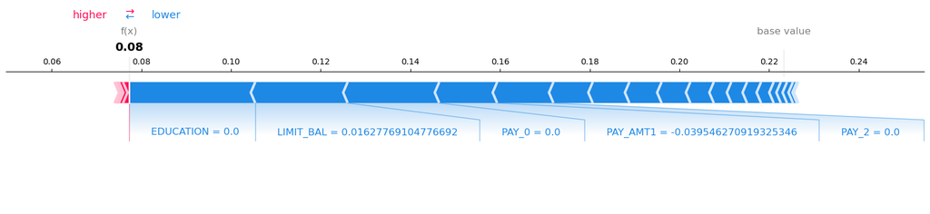

```python
shap.force_plot(
    rf_explainer.expected_value[1],
    test_rf_shap_values[1][ex_zero_index, :],
    X_test_enc.iloc[ex_zero_index, :],
    matplotlib=True,
)
```

```python
pd.DataFrame(
    test_rf_shap_values[1][ex_zero_index, :],
    index=feature_names,
    columns=["SHAP values"],
).sort_values('SHAP values', ascending=False)
```

|  | SHAP values |
| --- | --- |
| MARRIAGE | 0.001341 |
| ID | 0.000922 |
| PAY_6 | 0.000570 |
| AGE | 0.000401 |
| SEX | -0.000016 |
| PAY_AMT5 | -0.000298 |
| BILL_AMT3 | -0.000877 |
| BILL_AMT6 | -0.001317 |
| BILL_AMT4 | -0.001381 |
| BILL_AMT5 | -0.001591 |
| PAY_AMT3 | -0.002819 |
| PAY_AMT6 | -0.003129 |
| PAY_AMT2 | -0.003510 |
| BILL_AMT2 | -0.003902 |
| PAY_AMT4 | -0.005224 |
| PAY_4 | -0.006414 |
| PAY_5 | -0.007191 |
| BILL_AMT1 | -0.008164 |
| PAY_3 | -0.008766 |
| PAY_2 | -0.012555 |
| PAY_AMT1 | -0.012919 |
| PAY_0 | -0.020428 |
| LIMIT_BAL | -0.020607 |
| EDUCATION | -0.028159 |

In this individual prediction which predicted a 0 for `default.payment.next.month`. Recall that EDUCATION was the most important value, but with a negative weight (as seen in the SHAP value table above). So it being 0 is something that helped this person out the most (which is the highest education, as is expected). And all the other import features that we expected from Random Forest but which have a negtive weight, like `PAY_0` which is low and leading to a more comfortable prediction towards `0`. Effectively what this means is that this person is a highly education person who often pays in full and often on time, thus they are not predicted to default on their payments

```python
random_forest_model_new.named_steps["randomforestclassifier"].predict_proba(X_test_enc)[ex_one_index]
```

```
X has feature names, but RandomForestClassifier was fitted without feature names
```

```
array([0.51171431, 0.48828569])
```

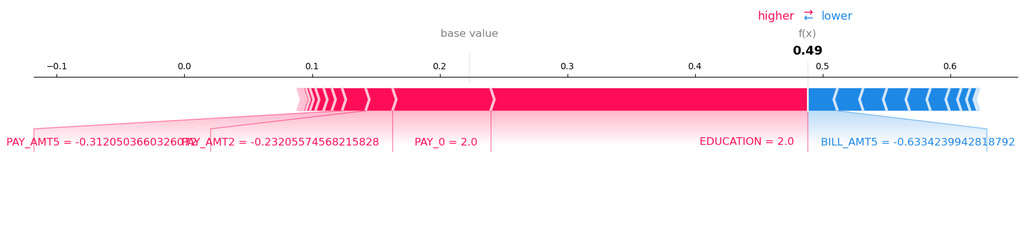

```python
shap.force_plot(
    rf_explainer.expected_value[1],
    test_rf_shap_values[1][ex_one_index, :],
    X_test_enc.iloc[ex_one_index, :],
    matplotlib=True,
)
```

```python
pd.DataFrame(
    test_rf_shap_values[1][ex_one_index, :],
    index=feature_names,
    columns=["SHAP values"],
).sort_values('SHAP values', ascending=False)
```

|  | SHAP values |
| --- | --- |
| EDUCATION | 0.248369 |
| PAY_0 | 0.076893 |
| PAY_AMT2 | 0.021084 |
| PAY_AMT5 | 0.018419 |
| BILL_AMT1 | 0.008004 |
| BILL_AMT4 | 0.006519 |
| BILL_AMT2 | 0.006364 |
| BILL_AMT6 | 0.004347 |
| PAY_AMT4 | 0.003076 |
| AGE | 0.002503 |
| PAY_AMT6 | 0.002017 |
| PAY_6 | 0.001040 |
| ID | 0.000861 |
| SEX | 0.000110 |
| MARRIAGE | -0.001412 |
| PAY_5 | -0.005756 |
| PAY_AMT1 | -0.007014 |
| PAY_3 | -0.009194 |
| PAY_4 | -0.014884 |
| BILL_AMT3 | -0.016382 |
| PAY_2 | -0.017738 |
| PAY_AMT3 | -0.018575 |
| LIMIT_BAL | -0.020135 |
| BILL_AMT5 | -0.023507 |